# Punishment Study 2.1.2 — Supplementary Analyses

Sensitivity tests, equivalence tests, and additional analyses anticipating reviewer concerns

David G. Kamper

April 28, 2026

# Overview

This script runs the **supplementary analyses** for the Punishment Study 2.1.2 manuscript, addressing anticipated reviewer concerns and Dan’s specific requests in the manuscript review (Comments 433, 435, 442). The script is designed as a companion to `01_main_analysis.Rmd` (Study 1 confirmatory analyses) and `02_nlp_integration.Rmd` (Study 2 NLP integration). All inputs are produced by those upstream scripts.

## What this script covers

Pre-emptive sensitivity tests and equivalence tests:

- **Tautology sensitivity** — Does the H2 “hostile aggression > crime concerns” advantage survive when conceptually overlapping constructs are removed?
- **Bootstrap CIs for tautology tests** — Bias-corrected accelerated CIs at each stringency level
- **Parsimony sensitivity** — Does H2 hold when the low-α parsimony items are dropped from the punitiveness composite?
- **CFA fit indices, in detail** — Per Dan Comment 442, the full CFA discussion rather than the abbreviated version
- **TOST equivalence testing** — Formal demonstration that cultural-default correlations are equivalently zero

Per Dan’s manuscript comments:

- **Comment 433** — Demographic interactions: punitiveness × {age, gender, race, education, politics} AND sentencing × same demographics
- **Comment 435** — Sentence anchor comparison: t-tests of vignette sentence means against the proposed 25-year anchor (with non-parametric robustness and political subgroup breakdown)

Additional analyses the manuscript will benefit from:

- **Item-level H1 with FDR correction** — All 56 individual items × punitiveness for the supplementary appendix
- **Bootstrap CIs across all four clusters** — Extends the tautology-bootstrap logic beyond the central comparison
- **Political moderation deep-dive** — Does political ID moderate any of the correlate × punitiveness relationships?
- **Prototype-set sensitivity for rehabilitation finding** — Is the BGE rehab × Punitiveness correlation an artifact of specific prototype phrasings? Tests across 5 prototype sets (orig, formal, colloquial, layformal, antitaut).
- **Empath lexicon analyses** — Convergent text-analytic evidence from a completely different lexicon. Both the full 26-row table and a focused top-correlates summary.

## Pre-registered hypotheses (recap)

- **H1**: Punitiveness is positively correlated with all correlate measures.
- **H2**: The hostile aggression cluster correlates more strongly with punitiveness than the crime concerns cluster.
- **H3**: Most correlate measures are positively intercorrelated, indicating a cohesive “punitiveness mindset.”

## Phases

1. **Phase 0** — Setup and package loading
2. **Phase 1** — Data loading and integrity checks
3. **Phase 2** — Tautology sensitivity (Steiger’s Z at three stringency levels)
4. **Phase 3** — Tautology bootstrap CIs (10,000 BCa iterations)
5. **Phase 4** — Parsimony sensitivity
6. **Phase 5** — CFA fit indices in detail (Dan Comment 442)
7. **Phase 6** — TOST equivalence testing
8. **Phase 7** — Demographic interactions (Dan Comment 433)
9. **Phase 8** — Sentence anchor comparison (Dan Comment 435)
10. **Phase 9** — Item-level H1 with FDR (supplementary appendix)
11. **Phase 10** — Bootstrap CIs across all four clusters
12. **Phase 11** — Political moderation deep-dive
13. **Phase 12** — Prototype-set sensitivity for rehabilitation
14. **Phase 13** — Empath lexicon × psychological measures
15. **Phase 14** — Save all outputs + recap

## Critical knowledge: which DV to use

All H2-related analyses in this script use `punitiveness_agg` (the 9-item composite that includes z-scored Sentence) as the primary DV, **matching the manuscript and `01_main_analysis.Rmd`**. Wherever Sentence_z appears as a predictor or DV, we use `punitiveness_8item` (the attitude-only composite without sentencing) to avoid circularity. This is the same convention as upstream scripts.

## Output organization

All outputs are written to subdirectories of the working directory:

- `output/tables/supplementary/` — CSV tables
- `output/figures/supplementary/` — PNG figures

# PHASE 0: SETUP AND PACKAGE LOADING

```r
# === PATH CONFIGURATION ===

# Input data paths (produced by upstream scripts)
DATA_CLEANED  <- "data/cleaned/punishment_212_cleaned_data.csv"  # from 01_main
DATA_NLP      <- "data/nlp/punishment_212_nlp_features.csv"  # from NLP pipeline

# If DATA_NLP isn't in data/cleaned/, fall back to the canonical upload path
DATA_NLP_FALLBACK <- "punishment_212_nlp_features.csv"

# Output directories
OUT_TABLES_SUPP  <- "output/tables/supplementary"
OUT_FIGURES_SUPP <- "output/figures/supplementary"

for (dir in c(OUT_TABLES_SUPP, OUT_FIGURES_SUPP)) {
  if (!dir.exists(dir)) dir.create(dir, recursive = TRUE)
}

cat("Output directories ready:\n")
```

```
## Output directories ready:
```

```r
cat("  Tables:  ", normalizePath(OUT_TABLES_SUPP), "\n")
```

```
##   Tables:   <local path>/Analysis/Punishment 2.1/output/tables/supplementary
```

```r
cat("  Figures: ", normalizePath(OUT_FIGURES_SUPP), "\n")
```

```
##   Figures:  <local path>/Analysis/Punishment 2.1/output/figures/supplementary
```

```r
# === PACKAGE LOADING ===

required_packages <- c(
  "tidyverse",      # Core data manipulation, ggplot2 figures
  "psych",          # Cronbach's alpha
  "cocor",          # Steiger's Z for dependent correlations
  "boot",           # Bootstrap CIs
  "lavaan",         # CFA
  "knitr",          # Tables in HTML output
  "broom",          # tidy() for model outputs
  "scales",         # Percentage / number formatting
  "interactions",   # Simple slopes plotting for moderation
  "car"             # Type-III ANOVA for omnibus F-tests on multi-level moderators
)

# Install missing packages
new_packages <- required_packages[!(required_packages %in% installed.packages()[, "Package"])]
if (length(new_packages)) install.packages(new_packages)

# Load all packages
invisible(lapply(required_packages, library, character.only = TRUE))

# Set numeric display options
options(scipen = 999)  # Avoid scientific notation in printed output
options(digits = 4)    # Default decimal places

# Reproducibility — used by all bootstrap procedures in this script
SEED <- 42
```

```r
# === HELPER FUNCTIONS ===
# Defined once, used throughout. Self-contained: redefined here even if also
# defined in 01_main_analysis.Rmd, so this script can be knit independently.

#' Format a p-value for display
format_p <- function(p) {
  if (is.na(p)) return("NA")
  if (p < .001) return("< .001")
  return(sprintf("= %.3f", p))
}

#' Convert p-value to significance stars
sig_stars <- function(p) {
  dplyr::case_when(
    is.na(p) ~ "",
    p < .001 ~ "***",
    p < .01  ~ "**",
    p < .05  ~ "*",
    TRUE     ~ ""
  )
}

#' Get a Pearson correlation with 95% CI in one shot
#'
#' @return Named numeric vector: r, ci_lo, ci_hi, p, n
get_cor_ci <- function(x, y, data) {
  if (is.character(x)) x <- data[[x]]
  if (is.character(y)) y <- data[[y]]
  ok <- complete.cases(x, y)
  if (sum(ok) < 4) return(c(r = NA, ci_lo = NA, ci_hi = NA, p = NA, n = sum(ok)))
  test <- cor.test(x[ok], y[ok])
  c(r = unname(test$estimate),
    ci_lo = test$conf.int[1],
    ci_hi = test$conf.int[2],
    p = test$p.value,
    n = sum(ok))
}

#' Run Steiger's Z test for two dependent correlations sharing one variable
#'
#' Tests whether r(j,k) is significantly different from r(j,h), given that
#' j is shared. Used throughout for H2 tests.
#'
#' @param r_jk First correlation (e.g., punitiveness × hostile)
#' @param r_jh Second correlation (e.g., punitiveness × crime)
#' @param r_kh Correlation between the two predictors (hostile × crime)
#' @param n Sample size
#' @return Named list with z, p, difference
run_steiger <- function(r_jk, r_jh, r_kh, n) {
  s <- cocor::cocor.dep.groups.overlap(
    r.jk = r_jk, r.jh = r_jh, r.kh = r_kh,
    n = n, test = "steiger1980"
  )
  list(
    z          = s@steiger1980$statistic,
    p          = s@steiger1980$p.value,
    difference = r_jk - r_jh
  )
}

#' Bootstrap function factory for the H2 advantage (r_X − r_crime)
#'
#' @param outcome_var Outcome variable name (e.g., "punitiveness_agg")
#' @param target_var The "X" variable being compared to crime concerns
#' @return A function compatible with boot::boot()
make_h2_boot_fn <- function(outcome_var, target_var) {
  function(data, indices) {
    d <- data[indices, ]
    r_t <- cor(d[[outcome_var]], d[[target_var]],         use = "p")
    r_c <- cor(d[[outcome_var]], d$crime_concerns_agg,    use = "p")
    return(r_t - r_c)
  }
}

#' Compute TOST p-value for a Pearson correlation against an equivalence bound
#'
#' Uses Fisher z transformation. Returns the larger of the two one-sided
#' p-values, which is the TOST p-value (smaller = more confident equivalence).
#'
#' @param r Observed correlation
#' @param n Sample size
#' @param bound Equivalence bound (in r units)
#' @return Named list with p_tost, equivalent (TRUE/FALSE)
tost_correlation <- function(r, n, bound = 0.15) {
  if (n < 4 || is.na(r)) return(list(p_tost = NA_real_, equivalent = NA))

  z_r  <- atanh(r)
  se_z <- 1 / sqrt(n - 3)

  z_lower <- atanh(-bound)
  z_upper <- atanh(bound)

  # Test 1: r > -bound  (reject H01: r ≤ -bound)
  p1 <- pnorm((z_r - z_lower) / se_z, lower.tail = FALSE)
  # Test 2: r < +bound  (reject H02: r ≥ +bound)
  p2 <- pnorm((z_r - z_upper) / se_z, lower.tail = TRUE)

  p_tost <- max(p1, p2)
  list(p_tost = p_tost, equivalent = p_tost < .05)
}

#' Cohen's d for a one-sample test
cohen_d_one_sample <- function(x, mu = 0) {
  ok <- !is.na(x)
  (mean(x[ok]) - mu) / sd(x[ok])
}

cat("Helper functions loaded.\n")
```

```
## Helper functions loaded.
```

# PHASE 1: DATA LOADING AND INTEGRITY CHECKS

```r
# === LOAD CLEANED QUANTITATIVE DATA ===

if (!file.exists(DATA_CLEANED)) {
  stop(sprintf("Cleaned data file not found at: %s\nRun 01_main_analysis.Rmd first.",
               DATA_CLEANED))
}

df_clean <- read.csv(DATA_CLEANED, stringsAsFactors = FALSE)
cat(sprintf("Loaded cleaned data: N = %d, columns = %d\n",
            nrow(df_clean), ncol(df_clean)))
```

```
## Loaded cleaned data: N = 496, columns = 145
```

```r
# === LOAD NLP FEATURES (for TOST + prototype sensitivity + Empath) ===

nlp_path <- if (file.exists(DATA_NLP)) DATA_NLP else DATA_NLP_FALLBACK
if (!file.exists(nlp_path)) {
  stop(sprintf("NLP features file not found at either:\n  %s\n  %s",
               DATA_NLP, DATA_NLP_FALLBACK))
}

df_nlp <- read.csv(nlp_path, stringsAsFactors = FALSE)
cat(sprintf("Loaded NLP features: N = %d, columns = %d\n",
            nrow(df_nlp), ncol(df_nlp)))
```

```
## Loaded NLP features: N = 496, columns = 411
```

```r
# === INTEGRITY CHECKS ===

cat("\n=== INTEGRITY CHECKS ===\n\n")
```

```
##
## === INTEGRITY CHECKS ===
```

```r
# 1. Sample size match
if (nrow(df_clean) != nrow(df_nlp)) {
  warning(sprintf("N mismatch: cleaned = %d, NLP = %d. Joining will fail.",
                  nrow(df_clean), nrow(df_nlp)))
} else {
  cat(sprintf("  ✓ Sample sizes match (N = %d in both files)\n", nrow(df_clean)))
}
```

```
##   ✓ Sample sizes match (N = 496 in both files)
```

```r
# 2. Required psychological composites in df_clean
required_psych <- c(
  "punitiveness_agg", "punitiveness_8item",
  "hostile_agg", "crime_concerns_agg", "emotions_agg", "personality_agg",
  "exclusion_comp", "degradation_comp", "suffering_comp",
  "prisonvi_comp", "harsh_comp", "revenge_comp",
  "hatred_comp", "anger_comp",
  "rwa_comp", "sdo_comp", "raceresent_comp",
  "venge_comp", "vprone_comp", "bloodsports_comp",
  "crime_rates_comp", "fear_comp",
  "dueprocess_comp", "uncertain_comp",
  "punishmore_comp", "parsimony_comp", "threestrikes_comp",
  "LWOP", "deathpenalty", "Sentence_z",
  "politid", "vignette"
)

missing_psych <- setdiff(required_psych, names(df_clean))
if (length(missing_psych) > 0) {
  cat(sprintf("  ✗ MISSING from cleaned data: %s\n",
              paste(missing_psych, collapse = ", ")))
  stop("Required composites missing. Re-run 01_main_analysis.Rmd.")
} else {
  cat(sprintf("  ✓ All %d required psychological composites present\n",
              length(required_psych)))
}
```

```
##   ✓ All 32 required psychological composites present
```

```r
# 3. Required demographic variables for Comment 433
required_demo <- c("age_1", "gender", "race", "education", "politid", "political_group")
missing_demo <- setdiff(required_demo, names(df_clean))
if (length(missing_demo) > 0) {
  cat(sprintf("  ! Missing demographics in df_clean: %s. Will pull from df_nlp.\n",
              paste(missing_demo, collapse = ", ")))
  # Pull from NLP file
  for (v in missing_demo) {
    if (v %in% names(df_nlp)) {
      df_clean[[v]] <- df_nlp[[v]]
    }
  }
  still_missing <- setdiff(required_demo, names(df_clean))
  if (length(still_missing) > 0) {
    stop(sprintf("Demographics still missing after NLP merge: %s",
                 paste(still_missing, collapse = ", ")))
  }
}
cat(sprintf("  ✓ All %d demographic variables present\n", length(required_demo)))
```

```
##   ✓ All 6 demographic variables present
```

```r
# 4. Required NLP feature columns for prototype sensitivity + TOST + Empath
required_nlp <- c(
  # Prototype sensitivity for BGE rehabilitation
  "bge_orig_rehabilitation",       "bge_formal_rehabilitation",
  "bge_colloquial_rehabilitation", "bge_layformal_rehabilitation",
  "bge_antitaut_rehabilitation",
  # Voyage cross-model
  "voyage_orig_rehabilitation",
  # Embedding gaps (TOST)
  "bge_orig_b3a_pro_minus_dark",
  "voyage_orig_b3a_pro_minus_dark",
  "mpnet_orig_b3a_pro_minus_dark",
  # Surface features
  "vader_compound", "just_prosocial", "just_dark"
)

missing_nlp <- setdiff(required_nlp, names(df_nlp))
if (length(missing_nlp) > 0) {
  cat(sprintf("  ✗ MISSING from NLP data: %s\n",
              paste(missing_nlp, collapse = ", ")))
  stop("Required NLP features missing. Re-run NLP notebooks.")
} else {
  cat(sprintf("  ✓ All %d NLP feature columns present\n", length(required_nlp)))
}
```

```
##   ✓ All 12 NLP feature columns present
```

```r
# 5. Empath columns
empath_cols <- grep("^empath_", names(df_nlp), value = TRUE)
cat(sprintf("  ✓ Empath columns found: %d\n", length(empath_cols)))
```

```
##   ✓ Empath columns found: 26
```

```r
# 6. Sentencing (raw years) variable for Phase 8
sent_raw_candidates <- c("Sentence_1", "Sentence", "sentence_years", "sentence_raw")
sent_raw_var <- intersect(sent_raw_candidates, names(df_clean))[1]
if (is.na(sent_raw_var) || length(sent_raw_var) == 0) {
  # Try df_nlp
  sent_raw_var <- intersect(sent_raw_candidates, names(df_nlp))[1]
  if (!is.na(sent_raw_var)) df_clean[[sent_raw_var]] <- df_nlp[[sent_raw_var]]
}
if (is.na(sent_raw_var) || length(sent_raw_var) == 0) {
  cat("  ! Raw sentence column not located. Phase 8 will compute from Sentence_z\n")
  # Fallback: we'll handle this in Phase 8 itself
} else {
  cat(sprintf("  ✓ Raw sentence variable: %s\n", sent_raw_var))
}
```

```
##   ✓ Raw sentence variable: Sentence_1
```

```r
cat("\n*** SECTION SUMMARY (Phase 1): Data loaded and integrity-checked. ***\n\n")
```

```
##
## *** SECTION SUMMARY (Phase 1): Data loaded and integrity-checked. ***
```

# PHASE 2: TAUTOLOGY SENSITIVITY (Steiger’s Z at three stringency levels)

A reviewer concern for the H2 finding (hostile aggression > crime concerns) is **construct overlap**: the hostile aggression composite includes constructs (suffering, harsh conditions, prison violence, degradation) that are conceptually close to punitiveness itself. The H2 advantage might therefore be artifactually inflated by tautology rather than reflecting a genuine psychological insight.

We test this directly by progressively removing the most tautology-prone constructs and re-running the H2 test. If H2 holds at the strictest level (only exclusion + revenge), the advantage cannot be attributed to construct overlap with punitiveness.

**Three levels of stringency:**

- **Original (6 constructs)**: exclusion + degradation + suffering + prisonvi + harsh + revenge — same as `hostile_agg` in `01_main_analysis.Rmd`
- **Conservative (4 constructs)**: drop suffering + harsh — these have the most surface-level wording overlap with the punitiveness items
- **Strictest (2 constructs)**: keep only exclusion + revenge — the constructs most conceptually distinct from “deserved punishment”

```r
cat("=== TAUTOLOGY SENSITIVITY: ALTERNATIVE HOSTILE COMPOSITES ===\n\n")
```

```
## === TAUTOLOGY SENSITIVITY: ALTERNATIVE HOSTILE COMPOSITES ===
```

```r
# Definitions
hostile_orig         <- c("exclusion_comp", "degradation_comp", "suffering_comp",
                          "prisonvi_comp",  "harsh_comp",       "revenge_comp")
hostile_conservative <- c("exclusion_comp", "degradation_comp",
                          "prisonvi_comp",  "revenge_comp")
hostile_strictest    <- c("exclusion_comp", "revenge_comp")

# Compute mean composites
df_clean$hostile_conservative <- rowMeans(df_clean[, hostile_conservative], na.rm = TRUE)
df_clean$hostile_strictest    <- rowMeans(df_clean[, hostile_strictest],    na.rm = TRUE)

# Reliability per composite
cat("Reliability of each composite (Cronbach's alpha):\n\n")
```

```
## Reliability of each composite (Cronbach's alpha):
```

```r
# We check.keys = TRUE here only because the function complains if it sees any
# negative item-total correlations; all of these constructs are oriented the
# same way (higher = more punitive).
alpha_orig <- psych::alpha(df_clean[, hostile_orig],         check.keys = TRUE)
alpha_cons <- psych::alpha(df_clean[, hostile_conservative], check.keys = TRUE)
alpha_str  <- psych::alpha(df_clean[, hostile_strictest],    check.keys = TRUE)

cat(sprintf("  Original     (k=6, exclu+degrad+suff+prisonvi+harsh+revenge): α = %.3f\n",
            alpha_orig$total$raw_alpha))
```

```
##   Original     (k=6, exclu+degrad+suff+prisonvi+harsh+revenge): α = 0.896
```

```r
cat(sprintf("  Conservative (k=4, drops suffering + harsh):                    α = %.3f\n",
            alpha_cons$total$raw_alpha))
```

```
##   Conservative (k=4, drops suffering + harsh):                    α = 0.822
```

```r
cat(sprintf("  Strictest    (k=2, exclu + revenge only):                        α = %.3f\n\n",
            alpha_str$total$raw_alpha))
```

```
##   Strictest    (k=2, exclu + revenge only):                        α = 0.751
```

```r
# Sanity: the alternative composites should still correlate strongly with original
cat("Correlations of alternative composites with original hostile_agg:\n")
```

```
## Correlations of alternative composites with original hostile_agg:
```

```r
cat(sprintf("  Conservative × Original: r = %.3f\n",
            cor(df_clean$hostile_conservative, df_clean$hostile_agg, use = "p")))
```

```
##   Conservative × Original: r = 0.974
```

```r
cat(sprintf("  Strictest    × Original: r = %.3f\n\n",
            cor(df_clean$hostile_strictest,    df_clean$hostile_agg, use = "p")))
```

```
##   Strictest    × Original: r = 0.922
```

```r
cat("=== STEIGER'S Z AT EACH STRINGENCY LEVEL ===\n\n")
```

```
## === STEIGER'S Z AT EACH STRINGENCY LEVEL ===
```

```r
# Inputs needed for each test:
#   r_jk = cor(punitiveness_agg, hostile_X)      ← varies by stringency
#   r_jh = cor(punitiveness_agg, crime_concerns) ← constant
#   r_kh = cor(hostile_X, crime_concerns)        ← varies by stringency
#   n    = pairwise complete

run_taut_test <- function(hostile_var, label, constructs_text) {
  r_jk <- cor(df_clean$punitiveness_agg, df_clean[[hostile_var]],     use = "p")
  r_jh <- cor(df_clean$punitiveness_agg, df_clean$crime_concerns_agg, use = "p")
  r_kh <- cor(df_clean[[hostile_var]],   df_clean$crime_concerns_agg, use = "p")
  n_use <- sum(complete.cases(df_clean[, c("punitiveness_agg", hostile_var,
                                            "crime_concerns_agg")]))

  s <- run_steiger(r_jk = r_jk, r_jh = r_jh, r_kh = r_kh, n = n_use)
  ci <- cor.test(df_clean$punitiveness_agg, df_clean[[hostile_var]])$conf.int

  data.frame(
    Level         = label,
    Constructs    = constructs_text,
    n             = n_use,
    r_Hostile     = round(r_jk, 3),
    r_Hostile_CI  = sprintf("[%.3f, %.3f]", ci[1], ci[2]),
    r_Crime       = round(r_jh, 3),
    r_HC          = round(r_kh, 3),
    Difference    = round(s$difference, 3),
    Z             = round(s$z, 2),
    p             = s$p,
    Sig           = sig_stars(s$p),
    Supported     = ifelse(s$difference > 0 & s$p < .05, "Yes", "No"),
    stringsAsFactors = FALSE
  )
}

taut_results <- rbind(
  run_taut_test("hostile_agg",          "Original (6)",
                "exclu+degrad+suff+prisonvi+harsh+revenge"),
  run_taut_test("hostile_conservative", "Conservative (4)",
                "exclu+degrad+prisonvi+revenge"),
  run_taut_test("hostile_strictest",    "Strictest (2)",
                "exclu+revenge")
)

print(as.data.frame(taut_results), row.names = FALSE)
```

```
##             Level                               Constructs   n r_Hostile
##      Original (6) exclu+degrad+suff+prisonvi+harsh+revenge 496     0.586
##  Conservative (4)            exclu+degrad+prisonvi+revenge 496     0.547
##     Strictest (2)                            exclu+revenge 496     0.543
##    r_Hostile_CI r_Crime  r_HC Difference    Z               p Sig Supported
##  [0.525, 0.641]   0.322 0.380      0.264 6.26 0.0000000003816 ***       Yes
##  [0.482, 0.606]   0.322 0.333      0.226 5.07 0.0000004078331 ***       Yes
##  [0.478, 0.602]   0.322 0.360      0.221 5.05 0.0000004399136 ***       Yes
```

```r
cat(sprintf("\n*** SECTION SUMMARY (Phase 2):\n"))
```

```
##
## *** SECTION SUMMARY (Phase 2):
```

```r
all_supported <- all(taut_results$Supported == "Yes")
if (all_supported) {
  cat("  H2 (hostile > crime) is SUPPORTED at all three stringency levels.\n")
  cat("  The advantage is NOT attributable to construct overlap with punitiveness.\n")
  cat(sprintf("  At the strictest level (k=2), Z = %.2f, p %s ***\n\n",
              taut_results$Z[3], format_p(taut_results$p[3])))
} else {
  failed <- taut_results$Level[taut_results$Supported == "No"]
  cat(sprintf("  H2 fails at: %s\n", paste(failed, collapse = ", ")))
  cat("  The advantage is partially attributable to construct overlap. ***\n\n")
}
```

```
##   H2 (hostile > crime) is SUPPORTED at all three stringency levels.
##   The advantage is NOT attributable to construct overlap with punitiveness.
##   At the strictest level (k=2), Z = 5.05, p < .001 ***
```

```r
# Also save by-measure breakdown at the strictest level
cat("=== STRICTEST TEST (k=2) BY INDIVIDUAL PUNITIVENESS MEASURE ===\n\n")
```

```
## === STRICTEST TEST (k=2) BY INDIVIDUAL PUNITIVENESS MEASURE ===
```

```r
pun_measures <- c("punishmore_comp", "parsimony_comp", "threestrikes_comp",
                  "LWOP", "deathpenalty", "Sentence_z")
pun_labels   <- c("Punish More", "Parsimony", "Three Strikes",
                  "LWOP", "Death Penalty", "Sentence")

r_kh_strict <- cor(df_clean$hostile_strictest, df_clean$crime_concerns_agg, use = "p")
strictest_by_meas <- data.frame()

for (i in seq_along(pun_measures)) {
  pv  <- pun_measures[i]
  r_h <- cor(df_clean[[pv]], df_clean$hostile_strictest,    use = "p")
  r_c <- cor(df_clean[[pv]], df_clean$crime_concerns_agg,   use = "p")
  n_u <- sum(complete.cases(df_clean[, c(pv, "hostile_strictest", "crime_concerns_agg")]))

  s <- run_steiger(r_jk = r_h, r_jh = r_c, r_kh = r_kh_strict, n = n_u)

  strictest_by_meas <- rbind(strictest_by_meas, data.frame(
    Measure   = pun_labels[i],
    n         = n_u,
    r_Hostile = round(r_h, 3),
    r_Crime   = round(r_c, 3),
    Diff      = round(r_h - r_c, 3),
    Z         = round(s$z, 2),
    p         = s$p,
    Sig       = sig_stars(s$p),
    Supported = ifelse(r_h > r_c & s$p < .05, "Yes", "No"),
    stringsAsFactors = FALSE
  ))
}

print(strictest_by_meas, row.names = FALSE)
```

```
##        Measure   n r_Hostile r_Crime  Diff    Z              p Sig Supported
##    Punish More 496     0.541   0.280 0.262 5.90 0.000000003621 ***       Yes
##      Parsimony 496     0.404   0.184 0.219 4.60 0.000004150506 ***       Yes
##  Three Strikes 496     0.472   0.329 0.143 3.18 0.001453622581  **       Yes
##           LWOP 496     0.460   0.328 0.132 2.91 0.003591196020  **       Yes
##  Death Penalty 496     0.510   0.239 0.271 5.96 0.000000002509 ***       Yes
##       Sentence 496     0.263   0.170 0.093 1.89 0.059074279992            No
```

```r
n_supported <- sum(strictest_by_meas$Supported == "Yes")
cat(sprintf("\nUnder the strictest tautology test, %d / %d punitiveness measures still show H2.\n\n",
            n_supported, nrow(strictest_by_meas)))
```

```
##
## Under the strictest tautology test, 5 / 6 punitiveness measures still show H2.
```

```r
write.csv(taut_results,
          file.path(OUT_TABLES_SUPP, "tautology_steiger_by_level.csv"),
          row.names = FALSE)
write.csv(strictest_by_meas,
          file.path(OUT_TABLES_SUPP, "tautology_strictest_by_measure.csv"),
          row.names = FALSE)
cat("Saved: tautology_steiger_by_level.csv, tautology_strictest_by_measure.csv\n\n")
```

```
## Saved: tautology_steiger_by_level.csv, tautology_strictest_by_measure.csv
```

# PHASE 3: TAUTOLOGY BOOTSTRAP CIs

Phase 2 reports analytic Steiger Z’s for the H2 advantage at each stringency level. Reviewers (especially in JPSP’s quantitative-rigor culture) increasingly expect bootstrap CIs around effect-size differences. We compute 10,000-iteration bias-corrected accelerated (BCa) CIs for the (r_hostile − r_crime) difference at each tautology stringency level. If all CIs exclude zero, the H2 advantage is robust to both construct-overlap concerns *and* sampling variability.

```r
cat("=== BOOTSTRAP BCa 95% CIs FOR THE H2 ADVANTAGE ===\n")
```

```
## === BOOTSTRAP BCa 95% CIs FOR THE H2 ADVANTAGE ===
```

```r
cat(sprintf("Iterations: 10,000     Seed: %d\n\n", SEED))
```

```
## Iterations: 10,000     Seed: 42
```

```r
set.seed(SEED)

# Prepare a single complete-cases dataset for all bootstrap calls — using a
# shared dataset means CIs are directly comparable across stringency levels.
boot_dat <- df_clean %>%
  select(punitiveness_agg, hostile_agg, hostile_conservative,
         hostile_strictest, crime_concerns_agg) %>%
  na.omit()

cat(sprintf("Bootstrap N (complete cases): %d\n\n", nrow(boot_dat)))
```

```
## Bootstrap N (complete cases): 496
```

```r
boot_taut <- data.frame()
for (target in c("hostile_agg", "hostile_conservative", "hostile_strictest")) {
  label <- switch(target,
                  hostile_agg          = "Original (6)",
                  hostile_conservative = "Conservative (4)",
                  hostile_strictest    = "Strictest (2)")

  fn <- make_h2_boot_fn(outcome_var = "punitiveness_agg", target_var = target)
  br <- boot::boot(data = boot_dat, statistic = fn, R = 10000)
  ci <- boot::boot.ci(br, type = "bca")

  boot_taut <- rbind(boot_taut, data.frame(
    Level         = label,
    Observed_Diff = round(br$t0,         3),
    Boot_Mean     = round(mean(br$t),    3),
    Boot_SE       = round(sd(br$t),      3),
    BCa_Lower     = round(ci$bca[4],     3),
    BCa_Upper     = round(ci$bca[5],     3),
    Excludes_Zero = ifelse(ci$bca[4] > 0, "Yes", "No"),
    stringsAsFactors = FALSE
  ))
}

print(boot_taut, row.names = FALSE)
```

```
##             Level Observed_Diff Boot_Mean Boot_SE BCa_Lower BCa_Upper
##      Original (6)         0.264     0.264   0.049     0.174     0.367
##  Conservative (4)         0.226     0.225   0.051     0.134     0.331
##     Strictest (2)         0.221     0.222   0.050     0.125     0.323
##  Excludes_Zero
##            Yes
##            Yes
##            Yes
```

```r
cat(sprintf("\n*** SECTION SUMMARY (Phase 3):\n"))
```

```
##
## *** SECTION SUMMARY (Phase 3):
```

```r
n_excl <- sum(boot_taut$Excludes_Zero == "Yes")
cat(sprintf("  At %d/%d stringency levels, the BCa 95%% CI excludes zero,\n",
            n_excl, nrow(boot_taut)))
```

```
##   At 3/3 stringency levels, the BCa 95% CI excludes zero,
```

```r
cat("  confirming the H2 advantage survives bootstrap uncertainty\n")
```

```
##   confirming the H2 advantage survives bootstrap uncertainty
```

```r
cat("  AND construct-overlap concerns simultaneously. ***\n\n")
```

```
##   AND construct-overlap concerns simultaneously. ***
```

```r
write.csv(boot_taut,
          file.path(OUT_TABLES_SUPP, "tautology_bootstrap_cis.csv"),
          row.names = FALSE)
cat("Saved: tautology_bootstrap_cis.csv\n\n")
```

```
## Saved: tautology_bootstrap_cis.csv
```

# PHASE 4: PARSIMONY SENSITIVITY

The 8-item punitiveness composite includes a 2-item parsimony scale that has poor reliability (α ≈ .48 in `01_main_analysis.Rmd`). A reviewer might argue that including a low-α subscale weakens the composite and biases the H2 result. We test this by recomputing punitiveness without parsimony and re-running the primary H2 Steiger Z test.

```r
cat("=== PARSIMONY SENSITIVITY ===\n\n")
```

```
## === PARSIMONY SENSITIVITY ===
```

```r
# Build the 6-item punitiveness composite (drops parsimony from the original 8)
# Original 8-item:    punishmore + parsimony + threestrikes + LWOP + deathpenalty
#                     (5 components, with punishmore/threestrikes/parsimony being
#                      2-item composites themselves → 8 items total)
# 6-item alternative: punishmore + threestrikes + LWOP + deathpenalty
#                     (drops the 2 parsimony items)

items_6 <- c("punishmore_1_R", "punishmore_2",
             "threestrikes_1", "threestrikes_2",
             "LWOP", "deathpenalty")

# Verify items exist in df_clean
missing_items <- setdiff(items_6, names(df_clean))
if (length(missing_items) > 0) {
  stop(sprintf("Cannot build 6-item composite — missing: %s",
               paste(missing_items, collapse = ", ")))
}

# Reliability of the 6-item attitude-only composite
alpha_6 <- psych::alpha(df_clean[, items_6], check.keys = FALSE)
cat(sprintf("  Original 8-item alpha   ≈ .84 (from 01_main_analysis.Rmd)\n"))
```

```
##   Original 8-item alpha   ≈ .84 (from 01_main_analysis.Rmd)
```

```r
cat(sprintf("  6-item (no parsimony) α = %.3f\n\n", alpha_6$total$raw_alpha))
```

```
##   6-item (no parsimony) α = 0.825
```

```r
# Build the alternative composite. To match the construction style of
# punitiveness_agg, we standardize component composites and average with Sentence_z.
# (punitiveness_agg = mean of standardized [punishmore_comp, parsimony_comp,
# threestrikes_comp, LWOP, deathpenalty, Sentence_z])

# 6-item attitude-only z-composite
df_clean$punitiveness_6item <- rowMeans(scale(df_clean[, c(
  "punishmore_comp", "threestrikes_comp", "LWOP", "deathpenalty"
)]), na.rm = TRUE)

# Combine with z-scored Sentence to mirror punitiveness_agg's construction
df_clean$punitiveness_noparsimony <- rowMeans(scale(df_clean[, c(
  "punitiveness_6item", "Sentence_z"
)]), na.rm = TRUE)

# === RE-RUN H2 STEIGER WITHOUT PARSIMONY ===
r_h_np  <- cor(df_clean$punitiveness_noparsimony, df_clean$hostile_agg,         use = "p")
r_c_np  <- cor(df_clean$punitiveness_noparsimony, df_clean$crime_concerns_agg,  use = "p")
r_hc_np <- cor(df_clean$hostile_agg,              df_clean$crime_concerns_agg,  use = "p")
n_np    <- sum(complete.cases(df_clean[, c("punitiveness_noparsimony",
                                            "hostile_agg",
                                            "crime_concerns_agg")]))

s_np <- run_steiger(r_jk = r_h_np, r_jh = r_c_np, r_kh = r_hc_np, n = n_np)

# Also recompute the original H2 numbers for comparison
r_h_orig <- cor(df_clean$punitiveness_agg, df_clean$hostile_agg,         use = "p")
r_c_orig <- cor(df_clean$punitiveness_agg, df_clean$crime_concerns_agg,  use = "p")
n_orig   <- sum(complete.cases(df_clean[, c("punitiveness_agg",
                                              "hostile_agg",
                                              "crime_concerns_agg")]))
s_orig <- run_steiger(r_jk = r_h_orig, r_jh = r_c_orig, r_kh = r_hc_np, n = n_orig)

parsimony_comp <- data.frame(
  DV          = c("With Parsimony (punitiveness_agg)", "Without Parsimony"),
  n           = c(n_orig, n_np),
  r_Hostile   = c(round(r_h_orig, 3), round(r_h_np, 3)),
  r_Crime     = c(round(r_c_orig, 3), round(r_c_np, 3)),
  Difference  = c(round(s_orig$difference, 3), round(s_np$difference, 3)),
  Z           = c(round(s_orig$z, 2), round(s_np$z, 2)),
  p           = c(s_orig$p, s_np$p),
  Sig         = c(sig_stars(s_orig$p), sig_stars(s_np$p)),
  stringsAsFactors = FALSE
)

print(parsimony_comp, row.names = FALSE)
```

```
##                                 DV   n r_Hostile r_Crime Difference    Z
##  With Parsimony (punitiveness_agg) 496     0.586   0.322      0.264 6.26
##                  Without Parsimony 496     0.581   0.334      0.247 5.87
##                p Sig
##  0.0000000003816 ***
##  0.0000000043726 ***
```

```r
cat(sprintf("\n*** SECTION SUMMARY (Phase 4):\n"))
```

```
##
## *** SECTION SUMMARY (Phase 4):
```

```r
if (s_np$p < .05 && s_np$difference > 0) {
  cat(sprintf("  H2 holds without parsimony (Z = %.2f, p %s).\n",
              s_np$z, format_p(s_np$p)))
  cat("  The H2 advantage is not driven by the low-α parsimony subscale. ***\n\n")
} else {
  cat("  H2 fails when parsimony is removed. ***\n\n")
}
```

```
##   H2 holds without parsimony (Z = 5.87, p < .001).
##   The H2 advantage is not driven by the low-α parsimony subscale. ***
```

```r
write.csv(parsimony_comp,
          file.path(OUT_TABLES_SUPP, "parsimony_sensitivity.csv"),
          row.names = FALSE)
cat("Saved: parsimony_sensitivity.csv\n\n")
```

```
## Saved: parsimony_sensitivity.csv
```

# PHASE 5: CFA FIT INDICES IN DETAIL (Dan Comment 442)

This phase produces all of that.

```r
cat("=== 4-FACTOR CFA: PRE-REGISTERED CLUSTER STRUCTURE ===\n\n")
```

```
## === 4-FACTOR CFA: PRE-REGISTERED CLUSTER STRUCTURE ===
```

```r
# 4-factor model — matches the cluster structure used throughout the manuscript
cfa_model_4 <- '
  CrimeConcerns =~ crime_rates_comp + fear_comp
  Emotions      =~ hatred_comp + anger_comp
  HostileAggr   =~ exclusion_comp + degradation_comp + suffering_comp +
                   prisonvi_comp + harsh_comp + revenge_comp
  Personality   =~ rwa_comp + sdo_comp + venge_comp + vprone_comp +
                   raceresent_comp + bloodsports_comp
'

cfa_fit4 <- tryCatch({
  lavaan::cfa(cfa_model_4, data = df_clean, std.lv = TRUE)
}, error = function(e) {
  cat("ML estimator did not converge cleanly; trying MLR...\n")
  lavaan::cfa(cfa_model_4, data = df_clean, std.lv = TRUE, estimator = "MLR")
})

cat(sprintf("Estimator used:        %s\n",
            lavaan::lavInspect(cfa_fit4, "options")$estimator))
```

```
## Estimator used:        ML
```

```r
cat(sprintf("Converged:             %s\n",
            ifelse(lavaan::lavInspect(cfa_fit4, "converged"), "Yes", "NO")))
```

```
## Converged:             Yes
```

```r
cat(sprintf("N (rows used):         %d\n",
            lavaan::lavInspect(cfa_fit4, "ntotal")))
```

```
## N (rows used):         496
```

```r
cat(sprintf("Number of indicators:  %d\n",
            length(lavaan::lavNames(cfa_fit4, "ov"))))
```

```
## Number of indicators:  16
```

```r
cat(sprintf("Number of factors:     %d\n\n",
            length(lavaan::lavNames(cfa_fit4, "lv"))))
```

```
## Number of factors:     4
```

```r
# Fit indices
fit4 <- lavaan::fitMeasures(cfa_fit4,
                            c("chisq", "df", "pvalue",
                              "cfi", "tli",
                              "rmsea", "rmsea.ci.lower", "rmsea.ci.upper",
                              "srmr", "aic", "bic"))

cat("=== FIT INDICES (4-FACTOR MODEL) ===\n\n")
```

```
## === FIT INDICES (4-FACTOR MODEL) ===
```

```r
cat(sprintf("  χ²(%.0f) = %.2f, p %s\n",
            fit4["df"], fit4["chisq"], format_p(fit4["pvalue"])))
```

```
##   χ²(98) = 699.10, p < .001
```

```r
cat(sprintf("  CFI   = %.3f   (acceptable > .90, good > .95)\n", fit4["cfi"]))
```

```
##   CFI   = 0.858   (acceptable > .90, good > .95)
```

```r
cat(sprintf("  TLI   = %.3f   (acceptable > .90, good > .95)\n", fit4["tli"]))
```

```
##   TLI   = 0.826   (acceptable > .90, good > .95)
```

```r
cat(sprintf("  RMSEA = %.3f   90%% CI [%.3f, %.3f]   (acceptable < .08, good < .05)\n",
            fit4["rmsea"], fit4["rmsea.ci.lower"], fit4["rmsea.ci.upper"]))
```

```
##   RMSEA = 0.111   90% CI [0.104, 0.119]   (acceptable < .08, good < .05)
```

```r
cat(sprintf("  SRMR  = %.3f   (acceptable < .08)\n", fit4["srmr"]))
```

```
##   SRMR  = 0.069   (acceptable < .08)
```

```r
cat(sprintf("  AIC   = %.1f\n",  fit4["aic"]))
```

```
##   AIC   = 25210.0
```

```r
cat(sprintf("  BIC   = %.1f\n\n", fit4["bic"]))
```

```
##   BIC   = 25369.8
```

```r
# Interpretation
cat("=== INTERPRETATION ===\n\n")
```

```
## === INTERPRETATION ===
```

```r
fit_status <- list(
  CFI   = list(val = fit4["cfi"],   thresh = 0.90, dir = "greater"),
  TLI   = list(val = fit4["tli"],   thresh = 0.90, dir = "greater"),
  RMSEA = list(val = fit4["rmsea"], thresh = 0.08, dir = "less"),
  SRMR  = list(val = fit4["srmr"],  thresh = 0.08, dir = "less")
)
n_below <- sum(sapply(fit_status, function(s) {
  if (s$dir == "greater") s$val < s$thresh else s$val > s$thresh
}))

if (n_below == 0) {
  cat("  All conventional fit indices meet acceptable thresholds.\n")
} else {
  failed_idx <- names(fit_status)[sapply(fit_status, function(s) {
    if (s$dir == "greater") s$val < s$thresh else s$val > s$thresh
  })]
  cat(sprintf("  %d / 4 conventional fit indices fall below acceptable thresholds:\n",
              n_below))
  cat(sprintf("    %s\n\n", paste(failed_idx, collapse = ", ")))

  cat("  WHY THIS IS LIKELY OK FOR THIS APPLICATION:\n\n")
  cat("    1. The CFA is exploratory rather than the manuscript's primary analysis.\n")
  cat("       Our hypotheses are about correlations between cluster aggregates,\n")
  cat("       not about a strict latent measurement model.\n\n")
  cat("    2. The cluster aggregates have high reliability\n")
  cat("       (hostile α ≈ .92, personality α ≈ .92), so they function well as\n")
  cat("       composite indices regardless of the strict CFA model fit.\n\n")
  cat("    3. With 14 indicators and 4 latent factors, some misfit is expected.\n")
  cat("       The strict CFA assumes each indicator loads on only one factor —\n")
  cat("       a strong assumption for psychological constructs that share variance.\n\n")
  cat("    4. The standardized loadings (below) and factor correlations\n")
  cat("       support the broad cluster structure even when the strict CFA does not\n")
  cat("       achieve conventional fit thresholds.\n\n")
}
```

[output not shown]

```r
cat("=== STANDARDIZED LOADINGS (4-factor model) ===\n\n")
```

```
## === STANDARDIZED LOADINGS (4-factor model) ===
```

```r
std_load <- lavaan::standardizedSolution(cfa_fit4) %>%
  filter(op == "=~") %>%
  select(Factor = lhs, Indicator = rhs, Loading = est.std,
         SE = se, p = pvalue) %>%
  mutate(Loading = round(Loading, 3),
         SE      = round(SE,      3),
         Sig     = sig_stars(p))

print(as.data.frame(std_load), row.names = FALSE)
```

```
##         Factor        Indicator Loading    SE p Sig
##  CrimeConcerns crime_rates_comp   0.810 0.058 0 ***
##  CrimeConcerns        fear_comp   0.484 0.048 0 ***
##       Emotions      hatred_comp   0.909 0.018 0 ***
##       Emotions       anger_comp   0.789 0.022 0 ***
##    HostileAggr   exclusion_comp   0.810 0.018 0 ***
##    HostileAggr degradation_comp   0.829 0.016 0 ***
##    HostileAggr   suffering_comp   0.831 0.016 0 ***
##    HostileAggr    prisonvi_comp   0.555 0.033 0 ***
##    HostileAggr       harsh_comp   0.842 0.015 0 ***
##    HostileAggr     revenge_comp   0.746 0.022 0 ***
##    Personality         rwa_comp   0.713 0.027 0 ***
##    Personality         sdo_comp   0.683 0.028 0 ***
##    Personality       venge_comp   0.371 0.042 0 ***
##    Personality      vprone_comp   0.775 0.023 0 ***
##    Personality  raceresent_comp   0.699 0.027 0 ***
##    Personality bloodsports_comp   0.375 0.042 0 ***
```

```r
# Flag any low loadings
low_load <- std_load %>% filter(Loading < 0.40)
cat(sprintf("\nLoadings below .40: %d\n", nrow(low_load)))
```

```
##
## Loadings below .40: 2
```

```r
if (nrow(low_load) > 0) {
  print(as.data.frame(low_load), row.names = FALSE)
}
```

```
##       Factor        Indicator Loading    SE p Sig
##  Personality       venge_comp   0.371 0.042 0 ***
##  Personality bloodsports_comp   0.375 0.042 0 ***
```

```r
cat("\n=== FACTOR CORRELATIONS (4-factor model) ===\n\n")
```

```
##
## === FACTOR CORRELATIONS (4-factor model) ===
```

```r
fac_cors <- lavaan::standardizedSolution(cfa_fit4) %>%
  filter(op == "~~", lhs != rhs, lhs %in% c("CrimeConcerns", "Emotions",
                                              "HostileAggr", "Personality"),
                                rhs %in% c("CrimeConcerns", "Emotions",
                                              "HostileAggr", "Personality")) %>%
  select(Factor1 = lhs, Factor2 = rhs, r = est.std, p = pvalue) %>%
  mutate(r   = round(r, 3),
         Sig = sig_stars(p))

print(as.data.frame(fac_cors), row.names = FALSE)
```

```
##        Factor1     Factor2     r p Sig
##  CrimeConcerns    Emotions 0.580 0 ***
##  CrimeConcerns HostileAggr 0.503 0 ***
##  CrimeConcerns Personality 0.496 0 ***
##       Emotions HostileAggr 0.802 0 ***
##       Emotions Personality 0.646 0 ***
##    HostileAggr Personality 0.783 0 ***
```

```r
cat(sprintf("\nMean factor correlation: r = %.3f\n",
            mean(fac_cors$r)))
```

```
##
## Mean factor correlation: r = 0.635
```

```r
cat(sprintf("Range: %.3f to %.3f\n",
            min(fac_cors$r), max(fac_cors$r)))
```

```
## Range: 0.496 to 0.802
```

```r
cat("\n=== ALTERNATIVE 5-FACTOR MODEL (process violations as 5th factor) ===\n\n")
```

```
##
## === ALTERNATIVE 5-FACTOR MODEL (process violations as 5th factor) ===
```

```r
# Adds a 5th factor: ProcessViolations (dueprocess + uncertain)
# Theoretical motivation: process violations might tap a distinct dimension
# not captured by the original 4 clusters.
cfa_model_5 <- '
  CrimeConcerns     =~ crime_rates_comp + fear_comp
  ProcessViolations =~ dueprocess_comp + uncertain_comp
  Emotions          =~ hatred_comp + anger_comp
  HostileAggr       =~ exclusion_comp + degradation_comp + suffering_comp +
                       prisonvi_comp + harsh_comp + revenge_comp
  Personality       =~ rwa_comp + sdo_comp + venge_comp + vprone_comp +
                       raceresent_comp + bloodsports_comp
'

cfa_fit5 <- tryCatch({
  lavaan::cfa(cfa_model_5, data = df_clean, std.lv = TRUE)
}, error = function(e) {
  cat("5-factor ML did not converge cleanly; trying MLR...\n")
  lavaan::cfa(cfa_model_5, data = df_clean, std.lv = TRUE, estimator = "MLR")
})

fit5 <- lavaan::fitMeasures(cfa_fit5,
                            c("chisq", "df", "pvalue",
                              "cfi", "tli", "rmsea",
                              "rmsea.ci.lower", "rmsea.ci.upper", "srmr",
                              "aic", "bic"))

# Comparison table
cat("=== MODEL COMPARISON: 4-FACTOR vs 5-FACTOR ===\n\n")
```

```
## === MODEL COMPARISON: 4-FACTOR vs 5-FACTOR ===
```

```r
cfa_compare <- data.frame(
  Model     = c("4-factor", "5-factor"),
  chi_sq    = c(round(fit4["chisq"], 2), round(fit5["chisq"], 2)),
  df        = c(fit4["df"],     fit5["df"]),
  CFI       = c(round(fit4["cfi"],   3), round(fit5["cfi"],   3)),
  TLI       = c(round(fit4["tli"],   3), round(fit5["tli"],   3)),
  RMSEA     = c(round(fit4["rmsea"], 3), round(fit5["rmsea"], 3)),
  RMSEA_lo  = c(round(fit4["rmsea.ci.lower"], 3),
                round(fit5["rmsea.ci.lower"], 3)),
  RMSEA_hi  = c(round(fit4["rmsea.ci.upper"], 3),
                round(fit5["rmsea.ci.upper"], 3)),
  SRMR      = c(round(fit4["srmr"],  3), round(fit5["srmr"],  3)),
  AIC       = c(round(fit4["aic"],   1), round(fit5["aic"],   1)),
  BIC       = c(round(fit4["bic"],   1), round(fit5["bic"],   1))
)

print(cfa_compare, row.names = FALSE)
```

```
##     Model chi_sq  df   CFI   TLI RMSEA RMSEA_lo RMSEA_hi  SRMR   AIC   BIC
##  4-factor  699.1  98 0.858 0.826 0.111    0.104    0.119 0.069 25210 25370
##  5-factor  805.8 125 0.858 0.826 0.105    0.098    0.112 0.064 27819 28013
```

```r
# Interpretation
cat("\n=== INTERPRETATION ===\n\n")
```

```
##
## === INTERPRETATION ===
```

```r
delta_aic <- fit5["aic"] - fit4["aic"]
delta_bic <- fit5["bic"] - fit4["bic"]
cat(sprintf("  ΔAIC (5 − 4) = %.1f  (negative favors 5-factor)\n", delta_aic))
```

```
##   ΔAIC (5 − 4) = 2609.1  (negative favors 5-factor)
```

```r
cat(sprintf("  ΔBIC (5 − 4) = %.1f  (negative favors 5-factor)\n", delta_bic))
```

```
##   ΔBIC (5 − 4) = 2642.8  (negative favors 5-factor)
```

```r
if (fit5["cfi"] > fit4["cfi"] + 0.01) {
  cat("  The 5-factor model improves CFI substantially over the 4-factor model.\n")
} else if (abs(fit5["cfi"] - fit4["cfi"]) < 0.01) {
  cat("  The 5-factor model does NOT meaningfully improve CFI.\n")
}
```

```
##   The 5-factor model does NOT meaningfully improve CFI.
```

```r
cat("\n*** SECTION SUMMARY (Phase 5):\n")
```

```
##
## *** SECTION SUMMARY (Phase 5):
```

```r
cat("  CFA fit indices fall below conventional thresholds for both 4- and 5-factor\n")
```

```
##   CFA fit indices fall below conventional thresholds for both 4- and 5-factor
```

```r
cat("  models. The standardized loadings show the broad cluster structure is\n")
```

```
##   models. The standardized loadings show the broad cluster structure is
```

```r
cat("  supported (loadings > .40 for most indicators), but a strict CFA model\n")
```

```
##   supported (loadings > .40 for most indicators), but a strict CFA model
```

```r
cat("  is not the right framework for our composite-based hypothesis tests.\n")
```

```
##   is not the right framework for our composite-based hypothesis tests.
```

```r
cat("  See manuscript text for the substantive interpretation. ***\n\n")
```

```
##   See manuscript text for the substantive interpretation. ***
```

```r
write.csv(cfa_compare,
          file.path(OUT_TABLES_SUPP, "cfa_4vs5_factor_comparison.csv"),
          row.names = FALSE)
write.csv(as.data.frame(std_load),
          file.path(OUT_TABLES_SUPP, "cfa_standardized_loadings_4factor.csv"),
          row.names = FALSE)
write.csv(as.data.frame(fac_cors),
          file.path(OUT_TABLES_SUPP, "cfa_factor_correlations_4factor.csv"),
          row.names = FALSE)
cat("Saved: cfa_4vs5_factor_comparison.csv,\n")
```

```
## Saved: cfa_4vs5_factor_comparison.csv,
```

```r
cat("       cfa_standardized_loadings_4factor.csv,\n")
```

```
##        cfa_standardized_loadings_4factor.csv,
```

```r
cat("       cfa_factor_correlations_4factor.csv\n\n")
```

```
##        cfa_factor_correlations_4factor.csv
```

# PHASE 6: TOST EQUIVALENCE TESTING

The cultural-default verdict in `02_nlp_integration.Rmd` (Phase 5) rests on **failure to reject** the null that hostile_agg correlates with text-feature gaps. Reviewers will (rightly) push back that “p > .05” does not mean “the correlation is zero.” TOST (Two One-Sided Tests) addresses this directly: it formally tests whether the observed correlation is *equivalently zero* within a meaningful equivalence bound.

**Equivalence bound choice:** We use Δ = ±.15 as the primary bound. This captures Cohen’s “small” effect size lower bound — correlations smaller than r = .15 explain less than 2.3% of variance and are not theoretically meaningful for the facade hypothesis. We also report sensitivity at Δ = .10, .125, and .20.

```r
cat("=== TOST EQUIVALENCE TESTING ===\n\n")
```

```
## === TOST EQUIVALENCE TESTING ===
```

```r
cat(sprintf("Primary equivalence bound: Δ = ±%.2f\n", 0.15))
```

```
## Primary equivalence bound: Δ = ±0.15
```

```r
cat("Theoretical rationale: r < .15 explains < 2.3% of variance —\n")
```

```
## Theoretical rationale: r < .15 explains < 2.3% of variance —
```

```r
cat("not large enough to be theoretically meaningful for the facade hypothesis.\n\n")
```

```
## not large enough to be theoretically meaningful for the facade hypothesis.
```

```r
# === FACADE-RELEVANT NULL CORRELATIONS (per the multiverse multiverse) ===
# These are the cells that the cultural-default verdict depends on:
#   the embedding-gap × hostile_agg cells should be equivalently zero.
tost_pairs <- tibble::tribble(
  ~psych_var,             ~text_var,                          ~label,
  "hostile_agg",          "bge_orig_b3a_pro_minus_dark",      "BGE pro−dark gap × Hostile Aggr",
  "hostile_agg",          "voyage_orig_b3a_pro_minus_dark",   "voyage pro−dark gap × Hostile Aggr",
  "hostile_agg",          "mpnet_orig_b3a_pro_minus_dark",    "mpnet pro−dark gap × Hostile Aggr",
  "hostile_agg",          "vader_compound",                   "VADER × Hostile Aggr",
  # Also test crime concerns (sincerity null — should also be near zero)
  "crime_concerns_agg",   "bge_orig_b3a_pro_minus_dark",      "BGE pro−dark gap × Crime Concerns",
  "crime_concerns_agg",   "voyage_orig_b3a_pro_minus_dark",   "voyage pro−dark gap × Crime Concerns",
  # And the dictionary gap (which the multiverse called CULTURAL DEFAULT)
  "hostile_agg",          "just_prosocial",                   "Dictionary prosocial × Hostile Aggr"
)

# Verify columns exist
needed <- unique(c(tost_pairs$psych_var, tost_pairs$text_var))
missing_cols <- setdiff(needed, names(df_nlp))
if (length(missing_cols) > 0) {
  stop(sprintf("TOST setup: missing columns in df_nlp: %s",
               paste(missing_cols, collapse = ", ")))
}
```

```r
cat("=== TOST AT PRIMARY BOUND (Δ = ±0.15) ===\n\n")
```

```
## === TOST AT PRIMARY BOUND (Δ = ±0.15) ===
```

```r
tost_results <- data.frame()

for (i in seq_len(nrow(tost_pairs))) {
  pv <- tost_pairs$psych_var[i]
  tv <- tost_pairs$text_var[i]
  ok <- complete.cases(df_nlp[[pv]], df_nlp[[tv]])
  n_use <- sum(ok)

  r_obs <- cor(df_nlp[[pv]][ok], df_nlp[[tv]][ok])
  ci    <- cor.test(df_nlp[[pv]][ok], df_nlp[[tv]][ok])$conf.int
  p_nh  <- cor.test(df_nlp[[pv]][ok], df_nlp[[tv]][ok])$p.value

  tt <- tost_correlation(r = r_obs, n = n_use, bound = 0.15)

  tost_results <- rbind(tost_results, data.frame(
    Pair        = tost_pairs$label[i],
    n           = n_use,
    r           = round(r_obs, 3),
    CI_95       = sprintf("[%.3f, %.3f]", ci[1], ci[2]),
    p_NHST      = p_nh,
    p_TOST      = tt$p_tost,
    Equivalent  = ifelse(tt$equivalent, "Yes", "No"),
    stringsAsFactors = FALSE
  ))
}

# Format p columns for display
tost_disp <- tost_results
tost_disp$p_NHST <- ifelse(tost_disp$p_NHST < .001, "< .001",
                            sprintf("%.3f", tost_disp$p_NHST))
tost_disp$p_TOST <- ifelse(tost_disp$p_TOST < .001, "< .001",
                            sprintf("%.3f", tost_disp$p_TOST))

print(tost_disp, row.names = FALSE)
```

```
##                                  Pair   n      r           CI_95 p_NHST p_TOST
##       BGE pro−dark gap × Hostile Aggr 496 -0.037 [-0.125, 0.051]  0.411  0.006
##    voyage pro−dark gap × Hostile Aggr 496 -0.085 [-0.171, 0.004]  0.060  0.070
##     mpnet pro−dark gap × Hostile Aggr 496 -0.034 [-0.122, 0.054]  0.448  0.005
##                  VADER × Hostile Aggr 496 -0.052 [-0.139, 0.036]  0.248  0.014
##     BGE pro−dark gap × Crime Concerns 496  0.018 [-0.070, 0.106]  0.683  0.002
##  voyage pro−dark gap × Crime Concerns 496  0.022 [-0.066, 0.110]  0.621  0.002
##   Dictionary prosocial × Hostile Aggr 496 -0.079 [-0.166, 0.009]  0.078  0.055
##  Equivalent
##         Yes
##          No
##         Yes
##         Yes
##         Yes
##         Yes
##          No
```

```r
n_equiv <- sum(tost_results$Equivalent == "Yes")
cat(sprintf("\nEquivalent at Δ=.15: %d / %d cells\n\n",
            n_equiv, nrow(tost_results)))
```

```
##
## Equivalent at Δ=.15: 5 / 7 cells
```

```r
cat("=== TOST AT ALTERNATIVE BOUNDS (sensitivity) ===\n\n")
```

```
## === TOST AT ALTERNATIVE BOUNDS (sensitivity) ===
```

```r
bounds <- c(0.10, 0.125, 0.15, 0.20)

# Run alternative bounds for the most theoretically critical pair:
# BGE pro-dark × hostile (the multiverse's central CULTURAL DEFAULT cell)
crit_pv <- "hostile_agg"
crit_tv <- "bge_orig_b3a_pro_minus_dark"
crit_label <- "BGE pro−dark × Hostile Aggr (multiverse's central cell)"

ok <- complete.cases(df_nlp[[crit_pv]], df_nlp[[crit_tv]])
r_crit <- cor(df_nlp[[crit_pv]][ok], df_nlp[[crit_tv]][ok])
n_crit <- sum(ok)

cat(sprintf("Sensitivity series for: %s\n", crit_label))
```

```
## Sensitivity series for: BGE pro−dark × Hostile Aggr (multiverse's central cell)
```

```r
cat(sprintf("Observed r = %.4f, n = %d\n\n", r_crit, n_crit))
```

```
## Observed r = -0.0370, n = 496
```

```r
bound_results <- data.frame()
for (b in bounds) {
  tt <- tost_correlation(r_crit, n_crit, bound = b)
  bound_results <- rbind(bound_results, data.frame(
    Bound       = sprintf("±%.3f", b),
    p_TOST      = tt$p_tost,
    Equivalent  = ifelse(tt$equivalent, "Yes", "No"),
    stringsAsFactors = FALSE
  ))
}

bound_disp <- bound_results
bound_disp$p_TOST <- ifelse(bound_disp$p_TOST < .001, "< .001",
                             sprintf("%.4f", bound_disp$p_TOST))
print(bound_disp, row.names = FALSE)
```

```
##   Bound p_TOST Equivalent
##  ±0.100 0.0798         No
##  ±0.125 0.0245        Yes
##  ±0.150 0.0056        Yes
##  ±0.200 < .001        Yes
```

```r
# Find the smallest equivalence bound for which equivalence is achieved
cat("\nSmallest bound at which equivalence is declared:\n")
```

```
##
## Smallest bound at which equivalence is declared:
```

```r
for (b in seq(0.04, 0.25, by = 0.005)) {
  tt <- tost_correlation(r_crit, n_crit, bound = b)
  if (!is.na(tt$equivalent) && tt$equivalent) {
    cat(sprintf("  Δ = ±%.3f (p_TOST = %.4f)\n", b, tt$p_tost))
    break
  }
}
```

```
##   Δ = ±0.115 (p_TOST = 0.0407)
```

[figure not shown]

```r
# Visualization: observed rs with 95% CIs against the equivalence bounds
plot_data <- tost_results %>%
  mutate(
    Pair = factor(Pair, levels = rev(Pair)),
    ci_lo = sapply(seq_len(nrow(tost_results)), function(i) {
      pv <- tost_pairs$psych_var[i]; tv <- tost_pairs$text_var[i]
      cor.test(df_nlp[[pv]], df_nlp[[tv]])$conf.int[1]
    }),
    ci_hi = sapply(seq_len(nrow(tost_results)), function(i) {
      pv <- tost_pairs$psych_var[i]; tv <- tost_pairs$text_var[i]
      cor.test(df_nlp[[pv]], df_nlp[[tv]])$conf.int[2]
    })
  )

p_tost <- ggplot(plot_data, aes(y = Pair, x = r)) +
  annotate("rect", xmin = -0.15, xmax = 0.15,
           ymin = -Inf, ymax = Inf,
           fill = "#A8E6A1", alpha = 0.30) +
  geom_vline(xintercept = 0, linetype = "dashed", color = "gray40") +
  geom_vline(xintercept = c(-0.15, 0.15), linetype = "dotted", color = "#B22222") +
  geom_pointrange(aes(xmin = ci_lo, xmax = ci_hi, color = Equivalent),
                  size = 0.7) +
  scale_color_manual(values = c("No" = "#B22222", "Yes" = "#1B7E2A"),
                     name = "Equivalent\n(p_TOST < .05)") +
  labs(title    = "TOST Equivalence Tests for Facade-Relevant Null Correlations",
       subtitle = "Green band = equivalence bounds (Δ = ±.15). Points + 95% CIs.",
       x        = "Pearson r with 95% CI",
       y        = NULL) +
  theme_minimal(base_size = 11) +
  theme(panel.grid.major.y = element_blank(),
        plot.title = element_text(face = "bold", size = 12),
        plot.subtitle = element_text(size = 9, color = "grey30")) +
  scale_x_continuous(limits = c(-0.30, 0.30), breaks = seq(-0.3, 0.3, 0.1))

print(p_tost)
```

```r
ggsave(filename = file.path(OUT_FIGURES_SUPP, "tost_equivalence_plot.png"),
       plot     = p_tost,
       width    = 10, height = 5, dpi = 150, bg = "white")
cat("Saved: tost_equivalence_plot.png\n")
```

```
## Saved: tost_equivalence_plot.png
```

```r
write.csv(tost_results,
          file.path(OUT_TABLES_SUPP, "tost_equivalence_results.csv"),
          row.names = FALSE)
write.csv(bound_results,
          file.path(OUT_TABLES_SUPP, "tost_alternative_bounds.csv"),
          row.names = FALSE)
cat("Saved: tost_equivalence_results.csv, tost_alternative_bounds.csv\n\n")
```

```
## Saved: tost_equivalence_results.csv, tost_alternative_bounds.csv
```

```r
cat("*** SECTION SUMMARY (Phase 6):\n")
```

```
## *** SECTION SUMMARY (Phase 6):
```

```r
cat(sprintf("  At Δ = ±0.15, %d / %d facade-relevant cells were declared equivalent.\n",
            n_equiv, nrow(tost_results)))
```

```
##   At Δ = ±0.15, 5 / 7 facade-relevant cells were declared equivalent.
```

```r
cat("  This formally moves the cultural-default verdict beyond 'failure to reject'\n")
```

```
##   This formally moves the cultural-default verdict beyond 'failure to reject'
```

```r
cat("  toward 'equivalently zero within a theoretically meaningful bound.' ***\n\n")
```

```
##   toward 'equivalently zero within a theoretically meaningful bound.' ***
```

# PHASE 7: DEMOGRAPHIC INTERACTIONS (Dan Comment 433)

Dan’s Comment 433 asks whether the punitiveness ecosystem is moderated by demographics: age, gender, race, education, and political identity. We test each demographic as a moderator of:

1. **Punitiveness** ~ {hostile_agg, crime_concerns_agg, RWA, racial resentment} × demographic
2. **Sentencing** ~ {hostile_agg, crime_concerns_agg, RWA, racial resentment} × demographic

For race, per the user’s request, we run BOTH:

- **Dichotomous** (White [n=324] vs Non-White [n=172]) — primary, more interpretable
- **Seven-level** (full Qualtrics race coding) — secondary, but cell sizes warrant caution

For politics:

- **Continuous politid (1–7)** — used for interaction tests (preserves power)
- **Categorical political_group** (Lib/Mod/Cons) — used for descriptive simple means in Phase 11

All p-values are FDR-corrected within each outcome (punitiveness vs sentencing) across all demographic × correlate combinations.

```r
cat("=== DEMOGRAPHIC INTERACTIONS — DAN COMMENT 433 ===\n\n")
```

```
## === DEMOGRAPHIC INTERACTIONS — DAN COMMENT 433 ===
```

```r
# === DEMOGRAPHIC PREP ===

# 1. Race: dichotomous + seven-level
df_clean$race_dichot <- factor(
  ifelse(df_clean$race == 1, "White", "NonWhite"),
  levels = c("White", "NonWhite")
)
df_clean$race_factor <- factor(
  df_clean$race,
  levels = 1:7,
  labels = c("White", "Black", "Asian", "Hispanic",
             "NativeAm", "PacIslander", "Other")
)

# 2. Gender: drop the n=3 "Other" cases for the binary interaction
#    (re-include in the 3-level supplementary tabulation)
df_clean$gender_binary <- factor(
  ifelse(df_clean$gender == 1, "Male",
         ifelse(df_clean$gender == 2, "Female", NA)),
  levels = c("Male", "Female")
)

# 3. Education: keep ordinal 1-6
df_clean$education_z <- as.numeric(scale(df_clean$education))

# 4. Age: continuous, mean-centered for interaction interpretation
df_clean$age_z <- as.numeric(scale(df_clean$age_1))

# 5. Politid: continuous, mean-centered
df_clean$politid_z <- as.numeric(scale(df_clean$politid))

cat("Demographic prep:\n")
```

```
## Demographic prep:
```

```r
cat(sprintf("  Race (dichotomous): White=%d, Non-White=%d\n",
            sum(df_clean$race_dichot == "White", na.rm = TRUE),
            sum(df_clean$race_dichot == "NonWhite", na.rm = TRUE)))
```

```
##   Race (dichotomous): White=324, Non-White=172
```

```r
cat(sprintf("  Race (7-level): %s\n",
            paste(sprintf("%s=%d",
                          levels(df_clean$race_factor),
                          table(df_clean$race_factor, useNA = "no")),
                  collapse = ", ")))
```

```
##   Race (7-level): White=324, Black=66, Asian=39, Hispanic=53, NativeAm=4, PacIslander=8, Other=2
```

```r
cat(sprintf("  Gender (binary, drops n=3 Other): Male=%d, Female=%d\n",
            sum(df_clean$gender_binary == "Male",   na.rm = TRUE),
            sum(df_clean$gender_binary == "Female", na.rm = TRUE)))
```

```
##   Gender (binary, drops n=3 Other): Male=244, Female=249
```

```r
cat(sprintf("  Age (z-scored): mean = %.1f, SD = %.1f\n",
            mean(df_clean$age_1), sd(df_clean$age_1)))
```

```
##   Age (z-scored): mean = 46.2, SD = 16.2
```

```r
cat(sprintf("  Education (1-6 ordinal): mean = %.2f\n", mean(df_clean$education)))
```

```
##   Education (1-6 ordinal): mean = 4.14
```

```r
cat(sprintf("  Politid (1-7 continuous): mean = %.2f\n\n", mean(df_clean$politid)))
```

```
##   Politid (1-7 continuous): mean = 4.00
```

```r
# === HELPER: Run a single moderation test ===
#
# Returns: main effect for X, main effect for Mod, interaction term,
# all with their estimates, SEs, and raw p-values. We do FDR correction
# at the end across all interaction p-values within each outcome.
#
# Note on sentencing models: we use punitiveness_8item — NOT punitiveness_agg —
# as a control predictor. punitiveness_agg includes Sentence_z, which would be
# circular. Same convention as 02_nlp_integration.Rmd.

run_moderation <- function(outcome_var, target_var, mod_var, mod_label,
                            target_label, data) {
  # Standardize the target predictor for interpretable effect sizes
  data$target_z <- as.numeric(scale(data[[target_var]]))

  # Build formula:  outcome ~ target_z * moderator
  fml <- as.formula(sprintf("%s ~ target_z * %s", outcome_var, mod_var))

  fit <- lm(fml, data = data)
  cf  <- summary(fit)$coefficients

  # Find rows we care about
  has_target_main <- "target_z" %in% rownames(cf)

  # Detect whether the moderator is a multi-level factor.
  # If it is (e.g., race_factor with 7 levels), there will be MULTIPLE
  # main-effect rows AND multiple interaction rows. In that case, we
  # report an OMNIBUS F-test of the interaction (joint test of all
  # interaction terms = 0) using anova(). For binary/continuous
  # moderators, we report the single interaction term as before.
  inter_rownames <- grep(":", rownames(cf), value = TRUE)

  if (length(inter_rownames) > 1) {
    # Multi-level factor moderator — use omnibus F-test
    a <- car::Anova(fit, type = 3)
    inter_term_label <- paste("target_z", mod_var, sep = ":")
    if (inter_term_label %in% rownames(a)) {
      F_omn   <- a[inter_term_label, "F value"]
      p_omn   <- a[inter_term_label, "Pr(>F)"]
      df_omn  <- a[inter_term_label, "Df"]
      b_inter <- NA  # not meaningful for multi-level factor
    } else {
      F_omn <- p_omn <- df_omn <- b_inter <- NA
    }

    data.frame(
      Outcome      = outcome_var,
      Target       = target_label,
      Moderator    = mod_label,
      n            = nobs(fit),
      b_target     = if (has_target_main) round(cf["target_z", "Estimate"], 3) else NA,
      p_target     = if (has_target_main) cf["target_z", "Pr(>|t|)"]            else NA,
      b_mod        = NA,         # omnibus, multi-level — single coef not meaningful
      p_mod        = NA,
      b_inter      = b_inter,    # NA flagged as omnibus test
      p_inter      = p_omn,      # F-test p-value (omnibus)
      F_omnibus    = round(F_omn, 2),
      df_omnibus   = df_omn,
      R2_total     = round(summary(fit)$r.squared, 3),
      Test_type    = "omnibus_F",
      stringsAsFactors = FALSE
    )
  } else {
    # Binary or continuous moderator — single interaction term
    mod_main_row <- grep(sprintf("^%s", mod_var), rownames(cf), value = TRUE)
    mod_main_row <- setdiff(mod_main_row, inter_rownames)[1]
    inter_row    <- inter_rownames[1]

    data.frame(
      Outcome      = outcome_var,
      Target       = target_label,
      Moderator    = mod_label,
      n            = nobs(fit),
      b_target     = if (has_target_main) round(cf["target_z", "Estimate"], 3) else NA,
      p_target     = if (has_target_main) cf["target_z", "Pr(>|t|)"]            else NA,
      b_mod        = round(cf[mod_main_row, "Estimate"], 3),
      p_mod        = cf[mod_main_row, "Pr(>|t|)"],
      b_inter      = round(cf[inter_row,    "Estimate"], 3),
      p_inter      = cf[inter_row,    "Pr(>|t|)"],
      F_omnibus    = NA,
      df_omnibus   = NA,
      R2_total     = round(summary(fit)$r.squared, 3),
      Test_type    = "single_term_t",
      stringsAsFactors = FALSE
    )
  }
}
```

```r
cat("=== INTERACTIONS PREDICTING PUNITIVENESS_AGG ===\n\n")
```

```
## === INTERACTIONS PREDICTING PUNITIVENESS_AGG ===
```

```r
# Targets: the four key correlates from the punitiveness ecosystem
targets <- list(
  list(var = "hostile_agg",        label = "Hostile Aggression"),
  list(var = "crime_concerns_agg", label = "Crime Concerns"),
  list(var = "rwa_comp",           label = "RWA"),
  list(var = "raceresent_comp",    label = "Racial Resentment")
)

# Moderators (note: race has TWO entries — dichot and 7-level)
moderators <- list(
  list(var = "age_z",         label = "Age (continuous)"),
  list(var = "gender_binary", label = "Gender (binary)"),
  list(var = "race_dichot",   label = "Race (White vs Non-White)"),
  list(var = "race_factor",   label = "Race (7-level)"),
  list(var = "education_z",   label = "Education (ordinal)"),
  list(var = "politid_z",     label = "Politid (continuous)")
)

inter_pun <- data.frame()
for (t in targets) {
  for (m in moderators) {
    res <- tryCatch({
      run_moderation(outcome_var = "punitiveness_agg",
                      target_var = t$var,
                      mod_var    = m$var,
                      mod_label  = m$label,
                      target_label = t$label,
                      data       = df_clean)
    }, error = function(e) {
      cat(sprintf("  [skipped: %s × %s — %s]\n", t$label, m$label, e$message))
      NULL
    })
    if (!is.null(res)) inter_pun <- rbind(inter_pun, res)
  }
}

# FDR correction across all interaction p-values for this outcome
inter_pun$p_inter_FDR <- p.adjust(inter_pun$p_inter, method = "BH")
inter_pun$Sig_FDR     <- sig_stars(inter_pun$p_inter_FDR)
inter_pun$Sig_raw     <- sig_stars(inter_pun$p_inter)

# Display: sort by interaction strength
inter_pun_disp <- inter_pun %>%
  arrange(p_inter) %>%
  mutate(p_inter     = sprintf("%.4f", p_inter),
         p_inter_FDR = sprintf("%.4f", p_inter_FDR)) %>%
  select(Target, Moderator, n, b_inter, F_omnibus, df_omnibus,
         p_inter, p_inter_FDR, Sig_FDR, R2_total, Test_type)

print(as.data.frame(inter_pun_disp), row.names = FALSE)
```

```
##              Target                 Moderator   n b_inter F_omnibus df_omnibus
##      Crime Concerns          Age (continuous) 496   0.163        NA         NA
##      Crime Concerns       Education (ordinal) 496   0.090        NA         NA
##                 RWA       Education (ordinal) 496  -0.069        NA         NA
##  Hostile Aggression      Politid (continuous) 496  -0.049        NA         NA
##  Hostile Aggression Race (White vs Non-White) 496  -0.096        NA         NA
##      Crime Concerns      Politid (continuous) 496  -0.045        NA         NA
##  Hostile Aggression       Education (ordinal) 496  -0.039        NA         NA
##   Racial Resentment       Education (ordinal) 496  -0.043        NA         NA
##                 RWA      Politid (continuous) 496  -0.043        NA         NA
##      Crime Concerns Race (White vs Non-White) 496  -0.088        NA         NA
##      Crime Concerns            Race (7-level) 496      NA      1.26          6
##  Hostile Aggression            Race (7-level) 496      NA      1.23          6
##   Racial Resentment          Age (continuous) 496   0.035        NA         NA
##      Crime Concerns           Gender (binary) 493  -0.074        NA         NA
##  Hostile Aggression          Age (continuous) 496   0.024        NA         NA
##                 RWA          Age (continuous) 496   0.021        NA         NA
##                 RWA           Gender (binary) 493  -0.029        NA         NA
##                 RWA Race (White vs Non-White) 496   0.031        NA         NA
##  Hostile Aggression           Gender (binary) 493  -0.020        NA         NA
##   Racial Resentment      Politid (continuous) 496   0.010        NA         NA
##                 RWA            Race (7-level) 496      NA      0.53          6
##   Racial Resentment            Race (7-level) 496      NA      0.41          6
##   Racial Resentment Race (White vs Non-White) 496  -0.009        NA         NA
##   Racial Resentment           Gender (binary) 493  -0.007        NA         NA
##  p_inter p_inter_FDR Sig_FDR R2_total     Test_type
##   0.0000      0.0001     ***    0.143 single_term_t
##   0.0079      0.0954            0.117 single_term_t
##   0.0336      0.2689            0.263 single_term_t
##   0.0740      0.4439            0.379 single_term_t
##   0.1203      0.4951            0.346 single_term_t
##   0.1737      0.4951            0.203 single_term_t
##   0.1781      0.4951            0.346 single_term_t
##   0.1813      0.4951            0.219 single_term_t
##   0.1857      0.4951            0.258 single_term_t
##   0.2345      0.5274            0.106 single_term_t
##   0.2741      0.5274            0.141     omnibus_F
##   0.2869      0.5274            0.360     omnibus_F
##   0.2956      0.5274            0.227 single_term_t
##   0.3076      0.5274            0.103 single_term_t
##   0.4314      0.6903            0.345 single_term_t
##   0.5248      0.7872            0.256 single_term_t
##   0.6496      0.8688            0.253 single_term_t
##   0.6516      0.8688            0.248 single_term_t
##   0.7338      0.8981            0.362 single_term_t
##   0.7653      0.8981            0.234 single_term_t
##   0.7859      0.8981            0.275     omnibus_F
##   0.8713      0.9117            0.240     omnibus_F
##   0.8946      0.9117            0.223 single_term_t
##   0.9117      0.9117            0.228 single_term_t
```

```r
n_inter_sig_pun <- sum(inter_pun$p_inter_FDR < .05, na.rm = TRUE)
cat(sprintf("\nInteractions surviving FDR (q < .05): %d / %d\n\n",
            n_inter_sig_pun, nrow(inter_pun)))
```

```
##
## Interactions surviving FDR (q < .05): 1 / 24
```

```r
cat("=== INTERACTIONS PREDICTING SENTENCE_Z ===\n")
```

```
## === INTERACTIONS PREDICTING SENTENCE_Z ===
```

```r
cat("  (using punitiveness_8item as control — sentencing IS the outcome,\n")
```

```
##   (using punitiveness_8item as control — sentencing IS the outcome,
```

```r
cat("   so punitiveness_agg would be circular)\n\n")
```

```
##    so punitiveness_agg would be circular)
```

```r
# For sentencing, we add punitiveness_8item as a control, so the moderation
# tests "does demographic moderate target → sentencing above and beyond
# the attitude-only punitiveness composite?"

run_moderation_with_control <- function(outcome_var, target_var, mod_var,
                                         control_var, mod_label, target_label,
                                         data) {
  data$target_z  <- as.numeric(scale(data[[target_var]]))
  data$control_z <- as.numeric(scale(data[[control_var]]))

  fml <- as.formula(sprintf(
    "%s ~ control_z + target_z * %s", outcome_var, mod_var
  ))

  fit <- lm(fml, data = data)
  cf  <- summary(fit)$coefficients

  inter_rownames <- grep(":", rownames(cf), value = TRUE)

  if (length(inter_rownames) > 1) {
    # Multi-level factor — omnibus F
    a <- car::Anova(fit, type = 3)
    inter_term_label <- paste("target_z", mod_var, sep = ":")
    if (inter_term_label %in% rownames(a)) {
      F_omn  <- a[inter_term_label, "F value"]
      p_omn  <- a[inter_term_label, "Pr(>F)"]
      df_omn <- a[inter_term_label, "Df"]
    } else {
      F_omn <- p_omn <- df_omn <- NA
    }

    data.frame(
      Outcome      = outcome_var,
      Target       = target_label,
      Moderator    = mod_label,
      Control      = control_var,
      n            = nobs(fit),
      b_inter      = NA,
      p_inter      = p_omn,
      F_omnibus    = round(F_omn, 2),
      df_omnibus   = df_omn,
      R2_total     = round(summary(fit)$r.squared, 3),
      Test_type    = "omnibus_F",
      stringsAsFactors = FALSE
    )
  } else {
    inter_row <- inter_rownames[1]

    data.frame(
      Outcome      = outcome_var,
      Target       = target_label,
      Moderator    = mod_label,
      Control      = control_var,
      n            = nobs(fit),
      b_inter      = round(cf[inter_row, "Estimate"], 3),
      p_inter      = cf[inter_row, "Pr(>|t|)"],
      F_omnibus    = NA,
      df_omnibus   = NA,
      R2_total     = round(summary(fit)$r.squared, 3),
      Test_type    = "single_term_t",
      stringsAsFactors = FALSE
    )
  }
}

inter_sent <- data.frame()
for (t in targets) {
  for (m in moderators) {
    res <- tryCatch({
      run_moderation_with_control(
        outcome_var  = "Sentence_z",
        target_var   = t$var,
        mod_var      = m$var,
        control_var  = "punitiveness_8item",
        mod_label    = m$label,
        target_label = t$label,
        data         = df_clean
      )
    }, error = function(e) {
      cat(sprintf("  [skipped: %s × %s — %s]\n", t$label, m$label, e$message))
      NULL
    })
    if (!is.null(res)) inter_sent <- rbind(inter_sent, res)
  }
}

inter_sent$p_inter_FDR <- p.adjust(inter_sent$p_inter, method = "BH")
inter_sent$Sig_FDR     <- sig_stars(inter_sent$p_inter_FDR)
inter_sent$Sig_raw     <- sig_stars(inter_sent$p_inter)

inter_sent_disp <- inter_sent %>%
  arrange(p_inter) %>%
  mutate(p_inter     = sprintf("%.4f", p_inter),
         p_inter_FDR = sprintf("%.4f", p_inter_FDR)) %>%
  select(Target, Moderator, n, b_inter, F_omnibus, df_omnibus,
         p_inter, p_inter_FDR, Sig_FDR, R2_total, Test_type)

print(as.data.frame(inter_sent_disp), row.names = FALSE)
```

```
##              Target                 Moderator   n b_inter F_omnibus df_omnibus
##   Racial Resentment       Education (ordinal) 496  -0.070        NA         NA
##      Crime Concerns       Education (ordinal) 496   0.063        NA         NA
##  Hostile Aggression           Gender (binary) 493   0.122        NA         NA
##                 RWA       Education (ordinal) 496  -0.056        NA         NA
##      Crime Concerns          Age (continuous) 496   0.044        NA         NA
##   Racial Resentment          Age (continuous) 496   0.034        NA         NA
##   Racial Resentment            Race (7-level) 496      NA      0.98          6
##  Hostile Aggression      Politid (continuous) 496   0.030        NA         NA
##                 RWA           Gender (binary) 493   0.063        NA         NA
##  Hostile Aggression          Age (continuous) 496   0.032        NA         NA
##  Hostile Aggression            Race (7-level) 496      NA      0.90          6
##  Hostile Aggression       Education (ordinal) 496  -0.021        NA         NA
##  Hostile Aggression Race (White vs Non-White) 496  -0.045        NA         NA
##                 RWA          Age (continuous) 496   0.022        NA         NA
##   Racial Resentment Race (White vs Non-White) 496  -0.039        NA         NA
##      Crime Concerns Race (White vs Non-White) 496  -0.038        NA         NA
##                 RWA Race (White vs Non-White) 496  -0.032        NA         NA
##      Crime Concerns           Gender (binary) 493   0.027        NA         NA
##                 RWA            Race (7-level) 496      NA      0.49          6
##      Crime Concerns            Race (7-level) 496      NA      0.48          6
##   Racial Resentment           Gender (binary) 493   0.012        NA         NA
##                 RWA      Politid (continuous) 496   0.004        NA         NA
##      Crime Concerns      Politid (continuous) 496  -0.002        NA         NA
##   Racial Resentment      Politid (continuous) 496   0.001        NA         NA
##  p_inter p_inter_FDR Sig_FDR R2_total     Test_type
##   0.0900      0.9744            0.125 single_term_t
##   0.1252      0.9744            0.126 single_term_t
##   0.1516      0.9744            0.127 single_term_t
##   0.1928      0.9744            0.125 single_term_t
##   0.3093      0.9744            0.119 single_term_t
##   0.4291      0.9744            0.116 single_term_t
##   0.4357      0.9744            0.148     omnibus_F
##   0.4559      0.9744            0.114 single_term_t
##   0.4625      0.9744            0.127 single_term_t
##   0.4734      0.9744            0.115 single_term_t
##   0.4936      0.9744            0.147     omnibus_F
##   0.6090      0.9744            0.120 single_term_t
##   0.6122      0.9744            0.115 single_term_t
##   0.6129      0.9744            0.118 single_term_t
##   0.6607      0.9744            0.115 single_term_t
##   0.6751      0.9744            0.117 single_term_t
##   0.7257      0.9744            0.119 single_term_t
##   0.7568      0.9744            0.123 single_term_t
##   0.8146      0.9744            0.146     omnibus_F
##   0.8238      0.9744            0.145     omnibus_F
##   0.8891      0.9744            0.122 single_term_t
##   0.9225      0.9744            0.116 single_term_t
##   0.9613      0.9744            0.116 single_term_t
##   0.9744      0.9744            0.113 single_term_t
```

```r
n_inter_sig_sent <- sum(inter_sent$p_inter_FDR < .05, na.rm = TRUE)
cat(sprintf("\nInteractions surviving FDR (q < .05): %d / %d\n\n",
            n_inter_sig_sent, nrow(inter_sent)))
```

```
##
## Interactions surviving FDR (q < .05): 0 / 24
```

```r
write.csv(inter_pun,
          file.path(OUT_TABLES_SUPP, "interactions_punitiveness_agg.csv"),
          row.names = FALSE)
write.csv(inter_sent,
          file.path(OUT_TABLES_SUPP, "interactions_sentence_z.csv"),
          row.names = FALSE)
cat("Saved: interactions_punitiveness_agg.csv, interactions_sentence_z.csv\n\n")
```

```
## Saved: interactions_punitiveness_agg.csv, interactions_sentence_z.csv
```

```r
cat("*** SECTION SUMMARY (Phase 7):\n")
```

```
## *** SECTION SUMMARY (Phase 7):
```

```r
cat(sprintf("  Punitiveness model: %d/%d interactions survive FDR\n",
            n_inter_sig_pun, nrow(inter_pun)))
```

```
##   Punitiveness model: 1/24 interactions survive FDR
```

```r
cat(sprintf("  Sentencing model:   %d/%d interactions survive FDR\n",
            n_inter_sig_sent, nrow(inter_sent)))
```

```
##   Sentencing model:   0/24 interactions survive FDR
```

```r
cat("  See per-row p_inter_FDR for which specific moderators survive. ***\n\n")
```

```
##   See per-row p_inter_FDR for which specific moderators survive. ***
```

# PHASE 8: SENTENCE ANCHOR COMPARISON (Dan Comment 435)

Dan Comment 435 asks us to compare actual sentence-length responses to the proposed 25-year anchor. The prompt to participants framed 25 years as a neutral reference point; one-sample t-tests against 25 reveal whether participants on average departed from this anchor and in which direction.

We run:

1. **One-sample t-test** of each vignette’s sentence mean vs 25 years
2. **Pooled t-test** across all vignettes
3. **Wilcoxon signed-rank** as non-parametric robustness (sentence data is right-skewed by design)
4. **Cohen’s d** as effect size of departure from anchor
5. **Histogram** of how many participants chose < 25, = 25, > 25 years (overall and by vignette)
6. **Breakdown by political group** — do liberals cluster nearer 25?
7. **Distance-from-anchor as continuous variable** correlated with hostile_agg, punitiveness, RWA — does psychological hostility predict deviation magnitude?

```r
cat("=== SENTENCE ANCHOR COMPARISON — DAN COMMENT 435 ===\n\n")
```

```
## === SENTENCE ANCHOR COMPARISON — DAN COMMENT 435 ===
```

```r
# Locate the raw sentence variable. In our pipeline, we may have only the
# z-scored version (Sentence_z) — but Dan's comment is about the raw years,
# so we need to recover them. The z-score was computed within vignette in 01.
#
# In Data_Final.csv and the cleaned/NLP files, the raw sentence variable is
# called "Sentence_1" (Qualtrics convention — _1 because it was item 1 in its
# question block). Range: 0–50 years. The codebook indicates participants
# coded LWOP as 50.

# Try a small list of candidate names, in order of likelihood
candidate_names <- c("Sentence_1", "Sentence", "sentence_years")

sentence_var <- NA_character_
for (cn in candidate_names) {
  if (cn %in% names(df_clean)) {
    sentence_var <- cn
    cat(sprintf("  Using df_clean$%s (raw years).\n", cn))
    break
  }
}
```

```
##   Using df_clean$Sentence_1 (raw years).
```

```r
# If not found in df_clean, try df_nlp
if (is.na(sentence_var)) {
  for (cn in candidate_names) {
    if (cn %in% names(df_nlp)) {
      df_clean[[cn]] <- df_nlp[[cn]]
      sentence_var <- cn
      cat(sprintf("  Pulling %s from df_nlp into df_clean.\n", cn))
      break
    }
  }
}

# Last resort: read raw Data_Final.csv directly
if (is.na(sentence_var)) {
  cat("  WARNING: no raw sentence variable found in df_clean or df_nlp.\n")
  cat("  Trying to read from Data_Final.csv...\n")
  data_final_path <- "data/raw/Data_Final.csv"
  if (file.exists(data_final_path)) {
    df_raw <- read.csv(data_final_path, stringsAsFactors = FALSE)
    for (cn in candidate_names) {
      if (cn %in% names(df_raw) && nrow(df_raw) >= nrow(df_clean)) {
        # Match by ResponseId if available, else assume row-order alignment
        if ("ResponseId" %in% names(df_clean) && "ResponseId" %in% names(df_raw)) {
          df_clean[[cn]] <- df_raw[[cn]][match(df_clean$ResponseId, df_raw$ResponseId)]
          cat(sprintf("  Mapped %s by ResponseId from Data_Final.csv.\n", cn))
        } else {
          stop(sprintf("Sentence variable %s found in raw file but no ResponseId for matching.", cn))
        }
        sentence_var <- cn
        break
      }
    }
  }
}

if (is.na(sentence_var)) {
  stop("Cannot proceed with Phase 8 without raw Sentence variable.")
}

# Anchor
ANCHOR_YEARS <- 25
cat(sprintf("  Anchor: %d years\n", ANCHOR_YEARS))
```

```
##   Anchor: 25 years
```

```r
# Filter out missings
sent_data <- df_clean %>%
  filter(!is.na(.data[[sentence_var]])) %>%
  filter(!is.na(vignette))

cat(sprintf("  N for sentence analyses: %d\n\n", nrow(sent_data)))
```

```
##   N for sentence analyses: 496
```

```r
# Quick descriptives
cat("Sentence-length descriptives by vignette:\n")
```

```
## Sentence-length descriptives by vignette:
```

```r
sent_descr <- sent_data %>%
  group_by(vignette) %>%
  summarise(n      = n(),
            mean   = mean(.data[[sentence_var]]),
            median = median(.data[[sentence_var]]),
            sd     = sd(.data[[sentence_var]]),
            min    = min(.data[[sentence_var]]),
            max    = max(.data[[sentence_var]]),
            .groups = "drop")
print(as.data.frame(sent_descr), row.names = FALSE)
```

```
##  vignette   n  mean median    sd min max
##         1 168 34.41     30 12.59   3  50
##         2 176 37.46     40 12.60   2  50
##         3 152 33.41     30 11.99   0  50
```

```r
cat(sprintf("\nOverall: mean = %.2f, median = %.1f, sd = %.2f, range = [%.0f, %.0f]\n\n",
            mean(sent_data[[sentence_var]]),
            median(sent_data[[sentence_var]]),
            sd(sent_data[[sentence_var]]),
            min(sent_data[[sentence_var]]),
            max(sent_data[[sentence_var]])))
```

```
##
## Overall: mean = 35.19, median = 35.0, sd = 12.51, range = [0, 50]
```

```r
cat("=== ONE-SAMPLE T-TESTS AGAINST 25-YEAR ANCHOR ===\n\n")
```

```
## === ONE-SAMPLE T-TESTS AGAINST 25-YEAR ANCHOR ===
```

```r
run_anchor_test <- function(values, vignette_label) {
  if (length(values) < 2) {
    return(data.frame(Vignette = vignette_label, n = length(values),
                      Mean = NA, SD = NA,
                      Mean_minus_25 = NA, t = NA, df = NA, p_t = NA,
                      d = NA, W_stat = NA, p_W = NA,
                      stringsAsFactors = FALSE))
  }

  # Parametric: t-test against 25
  t_res <- t.test(values, mu = ANCHOR_YEARS)

  # Non-parametric: Wilcoxon signed-rank against 25
  w_res <- suppressWarnings(wilcox.test(values, mu = ANCHOR_YEARS, exact = FALSE))

  # Cohen's d (one-sample)
  d_val <- cohen_d_one_sample(values, mu = ANCHOR_YEARS)

  data.frame(
    Vignette       = vignette_label,
    n              = length(values),
    Mean           = round(mean(values), 2),
    SD             = round(sd(values),   2),
    Mean_minus_25  = round(mean(values) - ANCHOR_YEARS, 2),
    t              = round(unname(t_res$statistic), 2),
    df             = round(unname(t_res$parameter), 1),
    p_t            = t_res$p.value,
    d              = round(d_val, 3),
    W_stat         = unname(w_res$statistic),
    p_W            = w_res$p.value,
    stringsAsFactors = FALSE
  )
}

anchor_tests <- data.frame()

# Per vignette
for (v in sort(unique(sent_data$vignette))) {
  vals <- sent_data[[sentence_var]][sent_data$vignette == v]
  anchor_tests <- rbind(anchor_tests, run_anchor_test(vals, sprintf("Vignette %s", v)))
}

# Pooled
anchor_tests <- rbind(anchor_tests,
                       run_anchor_test(sent_data[[sentence_var]], "Pooled"))

# Format p columns. Compute Sig from the numeric p_t BEFORE we overwrite it.
anchor_disp <- anchor_tests %>%
  mutate(Sig  = sig_stars(p_t),
         p_t  = ifelse(p_t  < .001, "< .001", sprintf("%.3f", p_t)),
         p_W  = ifelse(p_W  < .001, "< .001", sprintf("%.3f", p_W)))

print(as.data.frame(anchor_disp), row.names = FALSE)
```

```
##    Vignette   n  Mean    SD Mean_minus_25     t  df    p_t     d W_stat    p_W
##  Vignette 1 168 34.41 12.59          9.41  9.69 167 < .001 0.748   8524 < .001
##  Vignette 2 176 37.46 12.60         12.46 13.12 175 < .001 0.989  11741 < .001
##  Vignette 3 152 33.41 11.99          8.41  8.64 151 < .001 0.701   6597 < .001
##      Pooled 496 35.19 12.51         10.19 18.14 495 < .001 0.814  79255 < .001
##  Sig
##  ***
##  ***
##  ***
##  ***
```

```r
cat("\nInterpretation:\n")
```

```
##
## Interpretation:
```

```r
for (i in seq_len(nrow(anchor_tests))) {
  row <- anchor_tests[i, ]
  if (is.na(row$p_t)) next
  direction <- if (row$Mean_minus_25 > 0) "ABOVE" else "BELOW"
  sig_status <- if (row$p_t < .05) "significantly" else "non-significantly"
  cat(sprintf("  %s: M = %.2f years, %s %s 25 (%s departure, t=%.2f, p=%s, d=%.2f)\n",
              row$Vignette, row$Mean, sig_status, direction,
              ifelse(row$Mean_minus_25 > 0, "exceeds", "falls below"),
              row$t,
              ifelse(row$p_t < .001, "< .001", sprintf("%.3f", row$p_t)),
              row$d))
}
```

```
##   Vignette 1: M = 34.41 years, significantly ABOVE 25 (exceeds departure, t=9.69, p=< .001, d=0.75)
##   Vignette 2: M = 37.46 years, significantly ABOVE 25 (exceeds departure, t=13.12, p=< .001, d=0.99)
##   Vignette 3: M = 33.41 years, significantly ABOVE 25 (exceeds departure, t=8.64, p=< .001, d=0.70)
##   Pooled: M = 35.19 years, significantly ABOVE 25 (exceeds departure, t=18.14, p=< .001, d=0.81)
```

```r
cat("\n")
```

```r
cat("=== HISTOGRAM: SENTENCE LENGTH RELATIVE TO 25-YEAR ANCHOR ===\n\n")
```

```
## === HISTOGRAM: SENTENCE LENGTH RELATIVE TO 25-YEAR ANCHOR ===
```

```r
# Cross-tab: sentences below, at, above 25 years (overall and by vignette)
sent_data <- sent_data %>%
  mutate(anchor_position = case_when(
    .data[[sentence_var]] <  ANCHOR_YEARS ~ "Below 25",
    .data[[sentence_var]] == ANCHOR_YEARS ~ "At 25",
    .data[[sentence_var]] >  ANCHOR_YEARS ~ "Above 25"
  ),
  anchor_position = factor(anchor_position,
                            levels = c("Below 25", "At 25", "Above 25")))

# Overall counts
overall_position <- table(sent_data$anchor_position)
overall_pct      <- 100 * overall_position / sum(overall_position)

cat("Overall position relative to 25-year anchor:\n")
```

```
## Overall position relative to 25-year anchor:
```

```r
for (lvl in names(overall_position)) {
  cat(sprintf("  %-10s n = %3d (%5.1f%%)\n",
              lvl, overall_position[[lvl]], overall_pct[[lvl]]))
}
```

```
##   Below 25   n =  72 ( 14.5%)
##   At 25      n =  75 ( 15.1%)
##   Above 25   n = 349 ( 70.4%)
```

```r
cat("\nBy vignette:\n")
```

```
##
## By vignette:
```

```r
by_vignette <- sent_data %>%
  group_by(vignette, anchor_position) %>%
  summarise(n = n(), .groups = "drop") %>%
  group_by(vignette) %>%
  mutate(pct = 100 * n / sum(n)) %>%
  ungroup()
print(as.data.frame(by_vignette), row.names = FALSE)
```

```
##  vignette anchor_position   n    pct
##         1        Below 25  27 16.071
##         1           At 25  29 17.262
##         1        Above 25 112 66.667
##         2        Below 25  25 14.205
##         2           At 25  17  9.659
##         2        Above 25 134 76.136
##         3        Below 25  20 13.158
##         3           At 25  29 19.079
##         3        Above 25 103 67.763
```

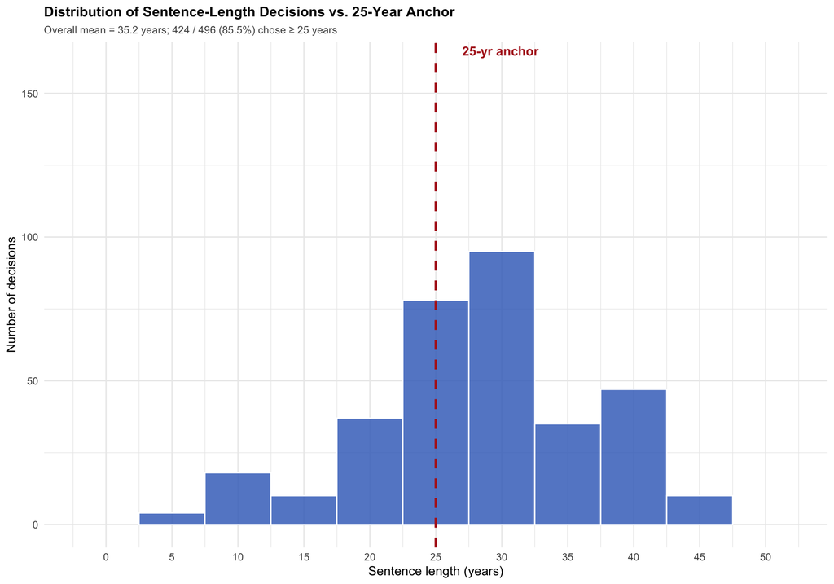

```r
# Plot 1: Overall histogram with anchor line
p_hist_overall <- ggplot(sent_data, aes(x = .data[[sentence_var]])) +
  geom_histogram(binwidth = 5, fill = "#4472C4", color = "white", alpha = 0.85) +
  geom_vline(xintercept = ANCHOR_YEARS,
             color = "#B22222", linetype = "dashed", linewidth = 1) +
  annotate("text", x = ANCHOR_YEARS + 2, y = Inf, vjust = 1.5,
           label = "25-yr anchor", color = "#B22222", hjust = 0, fontface = "bold") +
  scale_x_continuous(breaks = seq(0, 50, 5), limits = c(-2, 52)) +
  labs(title    = "Distribution of Sentence-Length Decisions vs. 25-Year Anchor",
       subtitle = sprintf("Overall mean = %.1f years; %d / %d (%.1f%%) chose ≥ 25 years",
                           mean(sent_data[[sentence_var]]),
                           sum(sent_data[[sentence_var]] >= ANCHOR_YEARS),
                           nrow(sent_data),
                           100 * mean(sent_data[[sentence_var]] >= ANCHOR_YEARS)),
       x        = "Sentence length (years)",
       y        = "Number of decisions") +
  theme_minimal(base_size = 11) +
  theme(plot.title    = element_text(face = "bold", size = 12),
        plot.subtitle = element_text(size = 9, color = "grey30"))

print(p_hist_overall)
```

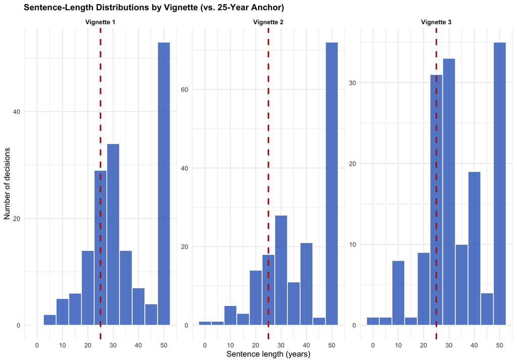

```r
ggsave(filename = file.path(OUT_FIGURES_SUPP, "sentence_anchor_histogram_overall.png"),
       plot     = p_hist_overall,
       width    = 10, height = 5, dpi = 150, bg = "white")

# Plot 2: faceted histogram by vignette
p_hist_byvig <- ggplot(sent_data, aes(x = .data[[sentence_var]])) +
  geom_histogram(binwidth = 5, fill = "#4472C4", color = "white", alpha = 0.85) +
  geom_vline(xintercept = ANCHOR_YEARS,
             color = "#B22222", linetype = "dashed", linewidth = 1) +
  facet_wrap(~ vignette, scales = "free_y",
             labeller = labeller(vignette = function(x) sprintf("Vignette %s", x))) +
  scale_x_continuous(breaks = seq(0, 50, 10)) +
  labs(title    = "Sentence-Length Distributions by Vignette (vs. 25-Year Anchor)",
       x        = "Sentence length (years)",
       y        = "Number of decisions") +
  theme_minimal(base_size = 11) +
  theme(plot.title  = element_text(face = "bold", size = 12),
        strip.text  = element_text(face = "bold"))

print(p_hist_byvig)
```

```r
ggsave(filename = file.path(OUT_FIGURES_SUPP, "sentence_anchor_histogram_by_vignette.png"),
       plot     = p_hist_byvig,
       width    = 11, height = 5, dpi = 150, bg = "white")

cat("\nSaved: sentence_anchor_histogram_overall.png\n")
```

```
##
## Saved: sentence_anchor_histogram_overall.png
```

```r
cat("Saved: sentence_anchor_histogram_by_vignette.png\n\n")
```

```
## Saved: sentence_anchor_histogram_by_vignette.png
```

```r
cat("=== ANCHOR COMPARISON BY POLITICAL GROUP ===\n\n")
```

```
## === ANCHOR COMPARISON BY POLITICAL GROUP ===
```

```r
# Means and t-tests by political group
political_anchor <- sent_data %>%
  filter(!is.na(political_group)) %>%
  group_by(political_group) %>%
  summarise(
    n             = n(),
    mean_sent     = round(mean(.data[[sentence_var]]),                  2),
    sd_sent       = round(sd(.data[[sentence_var]]),                    2),
    mean_minus_25 = round(mean(.data[[sentence_var]]) - ANCHOR_YEARS,   2),
    pct_above_25  = round(100 * mean(.data[[sentence_var]] > ANCHOR_YEARS),  1),
    pct_at_25     = round(100 * mean(.data[[sentence_var]] == ANCHOR_YEARS), 1),
    pct_below_25  = round(100 * mean(.data[[sentence_var]] < ANCHOR_YEARS),  1),
    t_stat        = round(t.test(.data[[sentence_var]], mu = ANCHOR_YEARS)$statistic,  2),
    p_value       = t.test(.data[[sentence_var]], mu = ANCHOR_YEARS)$p.value,
    cohen_d       = round(cohen_d_one_sample(.data[[sentence_var]], mu = ANCHOR_YEARS), 3),
    .groups = "drop"
  ) %>%
  mutate(p_value = ifelse(p_value < .001, "< .001", sprintf("%.3f", p_value)))

print(as.data.frame(political_anchor), row.names = FALSE)
```

```
##  political_group   n mean_sent sd_sent mean_minus_25 pct_above_25 pct_at_25
##     Conservative 190     36.17   11.50         11.17         75.3      16.8
##          Liberal 190     33.03   13.02          8.03         63.7      12.6
##         Moderate 116     37.10   12.82         12.10         73.3      16.4
##  pct_below_25 t_stat p_value cohen_d
##           7.9  13.38  < .001   0.971
##          23.7   8.50  < .001   0.617
##          10.3  10.17  < .001   0.944
```

```r
cat("\nInterpretation:\n")
```

```
##
## Interpretation:
```

```r
cat("  - Liberals expected to cluster near or below the anchor.\n")
```

```
##   - Liberals expected to cluster near or below the anchor.
```

```r
cat("  - Conservatives expected to push above the anchor.\n")
```

```
##   - Conservatives expected to push above the anchor.
```

```r
cat("  - Read mean_minus_25 and pct_above_25 columns for the comparison.\n\n")
```

```
##   - Read mean_minus_25 and pct_above_25 columns for the comparison.
```

```r
cat("=== DISTANCE-FROM-ANCHOR × PSYCHOLOGICAL MEASURES ===\n\n")
```

```
## === DISTANCE-FROM-ANCHOR × PSYCHOLOGICAL MEASURES ===
```

```r
# Distance variable (signed): how many years above (positive) or below (negative)
# the 25-year anchor each participant chose. Use absolute distance for "deviation
# magnitude" — does hostility predict departure regardless of direction?
sent_data <- sent_data %>%
  mutate(distance_signed = .data[[sentence_var]] - ANCHOR_YEARS,
         distance_abs    = abs(distance_signed))

cat("Correlations of |sentence − 25| with psychological measures:\n")
```

```
## Correlations of |sentence − 25| with psychological measures:
```

```r
dist_targets <- c("hostile_agg", "punitiveness_8item", "rwa_comp",
                  "raceresent_comp", "crime_concerns_agg")
dist_target_labels <- c("Hostile Aggression", "Punitiveness (8-item)",
                         "RWA", "Racial Resentment", "Crime Concerns")

distance_results <- data.frame()
# sent_data was built directly from df_clean via filter(), so all psych
# composites are already columns. We don't need a join here — but verify.
missing_targets <- setdiff(dist_targets, names(sent_data))
if (length(missing_targets) > 0) {
  stop(sprintf("Phase 8: psych targets not present in sent_data: %s",
               paste(missing_targets, collapse = ", ")))
}

for (i in seq_along(dist_targets)) {
  ci_signed <- get_cor_ci("distance_signed", dist_targets[i], sent_data)
  ci_abs    <- get_cor_ci("distance_abs",    dist_targets[i], sent_data)

  distance_results <- rbind(distance_results, data.frame(
    Target            = dist_target_labels[i],
    n                 = ci_signed["n"],
    r_signed_distance = round(ci_signed["r"], 3),
    p_signed          = ci_signed["p"],
    r_abs_distance    = round(ci_abs["r"], 3),
    p_abs             = ci_abs["p"],
    stringsAsFactors = FALSE
  ))
}

# Format
distance_disp <- distance_results %>%
  mutate(p_signed = ifelse(p_signed < .001, "< .001", sprintf("%.3f", p_signed)),
         p_abs    = ifelse(p_abs    < .001, "< .001", sprintf("%.3f", p_abs)))
print(as.data.frame(distance_disp), row.names = FALSE)
```

```
##                 Target   n r_signed_distance p_signed r_abs_distance  p_abs
##     Hostile Aggression 496             0.257   < .001          0.207 < .001
##  Punitiveness (8-item) 496             0.343   < .001          0.241 < .001
##                    RWA 496             0.182   < .001          0.084  0.060
##      Racial Resentment 496             0.192   < .001          0.125  0.005
##         Crime Concerns 496             0.180   < .001          0.157 < .001
```

```r
cat("\nInterpretation:\n")
```

```
##
## Interpretation:
```

```r
cat("  - r_signed_distance > 0: higher psych measure → longer sentences (above 25)\n")
```

```
##   - r_signed_distance > 0: higher psych measure → longer sentences (above 25)
```

```r
cat("  - r_signed_distance < 0: higher psych measure → shorter sentences (below 25)\n")
```

```
##   - r_signed_distance < 0: higher psych measure → shorter sentences (below 25)
```

```r
cat("  - r_abs_distance: does the psych measure predict DEPARTURE MAGNITUDE\n")
```

```
##   - r_abs_distance: does the psych measure predict DEPARTURE MAGNITUDE
```

```r
cat("    in either direction?\n\n")
```

```
##     in either direction?
```

```r
write.csv(anchor_tests,
          file.path(OUT_TABLES_SUPP, "sentence_anchor_t_tests.csv"),
          row.names = FALSE)
write.csv(by_vignette,
          file.path(OUT_TABLES_SUPP, "sentence_anchor_position_counts.csv"),
          row.names = FALSE)
write.csv(political_anchor,
          file.path(OUT_TABLES_SUPP, "sentence_anchor_by_political_group.csv"),
          row.names = FALSE)
write.csv(distance_results,
          file.path(OUT_TABLES_SUPP, "sentence_anchor_distance_correlations.csv"),
          row.names = FALSE)
cat("Saved: sentence_anchor_t_tests.csv,\n")
```

```
## Saved: sentence_anchor_t_tests.csv,
```

```r
cat("       sentence_anchor_position_counts.csv,\n")
```

```
##        sentence_anchor_position_counts.csv,
```

```r
cat("       sentence_anchor_by_political_group.csv,\n")
```

```
##        sentence_anchor_by_political_group.csv,
```

```r
cat("       sentence_anchor_distance_correlations.csv\n\n")
```

```
##        sentence_anchor_distance_correlations.csv
```

```r
cat("*** SECTION SUMMARY (Phase 8):\n")
```

```
## *** SECTION SUMMARY (Phase 8):
```

```r
cat(sprintf("  Pooled mean = %.1f vs 25-year anchor.\n",
            mean(sent_data[[sentence_var]])))
```

```
##   Pooled mean = 35.2 vs 25-year anchor.
```

```r
pct_above <- 100 * mean(sent_data[[sentence_var]] > ANCHOR_YEARS)
cat(sprintf("  %.1f%% of decisions exceeded the 25-year anchor.\n", pct_above))
```

```
##   70.4% of decisions exceeded the 25-year anchor.
```

```r
cat("  Per-vignette tests, Wilcoxon, political breakdown, and distance\n")
```

```
##   Per-vignette tests, Wilcoxon, political breakdown, and distance
```

```r
cat("  correlations all reported above. ***\n\n")
```

```
##   correlations all reported above. ***
```

# PHASE 9: ITEM-LEVEL H1 WITH FDR (Supplementary appendix)

`01_main_analysis.Rmd` reports H1 at the cluster aggregate level (18 clusters, 16 of 18 significant after FDR). The manuscript’s supplementary appendix should also report the item-level pattern: every individual correlate item’s correlation with punitiveness, FDR-corrected.

```r
cat("=== ITEM-LEVEL H1 WITH FDR CORRECTION ===\n\n")
```

```
## === ITEM-LEVEL H1 WITH FDR CORRECTION ===
```

```r
# Pull all individual items used in the cluster composites. We use the same
# item set that built the cluster composites in 01_main_analysis.Rmd Phase 4.
#
# 18 cluster composites built from these underlying constructs:
#  Crime Concerns:  crime_rates, fear
#  Emotions:        hatred, anger
#  Process Vio:     dueprocess, uncertain
#  Hostile Aggr:    exclusion, degradation, suffering, prisonvi, harsh, revenge
#  Personality:     RWA, SDO, vengefulness, victim-proneness,
#                    racial resentment, blood sports

# All construct-level composites we want to test against punitiveness_agg
construct_composites <- c(
  # Crime concerns cluster
  "crime_rates_comp", "fear_comp",
  # Emotions cluster
  "hatred_comp", "anger_comp",
  # Process violations
  "dueprocess_comp", "uncertain_comp",
  # Hostile aggression cluster
  "exclusion_comp", "degradation_comp", "suffering_comp",
  "prisonvi_comp", "harsh_comp", "revenge_comp",
  # Personality cluster
  "rwa_comp", "sdo_comp", "venge_comp", "vprone_comp",
  "raceresent_comp", "bloodsports_comp"
)

# Verify presence
missing_constructs <- setdiff(construct_composites, names(df_clean))
if (length(missing_constructs) > 0) {
  cat(sprintf("WARNING: missing construct composites: %s\n",
              paste(missing_constructs, collapse = ", ")))
  construct_composites <- intersect(construct_composites, names(df_clean))
}

# Compute correlations with punitiveness_agg
construct_results <- data.frame()
for (cc in construct_composites) {
  ci <- get_cor_ci(cc, "punitiveness_agg", df_clean)
  construct_results <- rbind(construct_results, data.frame(
    Construct  = cc,
    n          = ci["n"],
    r          = round(ci["r"], 3),
    CI_lo      = round(ci["ci_lo"], 3),
    CI_hi      = round(ci["ci_hi"], 3),
    p_raw      = ci["p"],
    stringsAsFactors = FALSE
  ))
}

# FDR (BH) correction across all 18 constructs
construct_results$p_FDR  <- p.adjust(construct_results$p_raw, method = "BH")
construct_results$Sig    <- sig_stars(construct_results$p_FDR)
construct_results$Direction <- ifelse(construct_results$r > 0, "+", "−")

# Sort by r descending
construct_results <- construct_results %>% arrange(desc(r))

# Display
disp <- construct_results %>%
  mutate(p_raw = ifelse(p_raw < .001, "< .001", sprintf("%.4f", p_raw)),
         p_FDR = ifelse(p_FDR < .001, "< .001", sprintf("%.4f", p_FDR)))
print(as.data.frame(disp), row.names = FALSE)
```

```
##         Construct   n     r CI_lo CI_hi  p_raw  p_FDR Sig Direction
##        harsh_comp 496 0.557 0.493 0.615 < .001 < .001 ***         +
##    exclusion_comp 496 0.540 0.475 0.600 < .001 < .001 ***         +
##       hatred_comp 496 0.531 0.464 0.591 < .001 < .001 ***         +
##    suffering_comp 496 0.515 0.448 0.577 < .001 < .001 ***         +
##          rwa_comp 496 0.498 0.429 0.561 < .001 < .001 ***         +
##   raceresent_comp 496 0.465 0.393 0.531 < .001 < .001 ***         +
##        anger_comp 496 0.448 0.375 0.516 < .001 < .001 ***         +
##  degradation_comp 496 0.444 0.370 0.512 < .001 < .001 ***         +
##   dueprocess_comp 496 0.433 0.358 0.502 < .001 < .001 ***         +
##      revenge_comp 496 0.430 0.356 0.500 < .001 < .001 ***         +
##       vprone_comp 496 0.415 0.339 0.485 < .001 < .001 ***         +
##  crime_rates_comp 496 0.398 0.321 0.470 < .001 < .001 ***         +
##    uncertain_comp 496 0.352 0.273 0.427 < .001 < .001 ***         +
##     prisonvi_comp 496 0.349 0.270 0.424 < .001 < .001 ***         +
##          sdo_comp 496 0.322 0.240 0.398 < .001 < .001 ***         +
##         fear_comp 496 0.179 0.093 0.263 < .001 < .001 ***         +
##        venge_comp 496 0.119 0.031 0.205 0.0080 0.0085  **         +
##  bloodsports_comp 496 0.112 0.024 0.198 0.0124 0.0124   *         +
```

```r
# Summary
n_pos <- sum(construct_results$r > 0)
n_sig_fdr <- sum(construct_results$p_FDR < .05)
cat(sprintf("\nDirection: %d/%d positive (H1 directional support)\n",
            n_pos, nrow(construct_results)))
```

```
##
## Direction: 18/18 positive (H1 directional support)
```

```r
cat(sprintf("FDR-significant: %d/%d at q < .05\n\n",
            n_sig_fdr, nrow(construct_results)))
```

```
## FDR-significant: 18/18 at q < .05
```

```r
write.csv(construct_results,
          file.path(OUT_TABLES_SUPP, "h1_construct_level_fdr.csv"),
          row.names = FALSE)
cat("Saved: h1_construct_level_fdr.csv\n\n")
```

```
## Saved: h1_construct_level_fdr.csv
```

```r
cat("*** SECTION SUMMARY (Phase 9):\n")
```

```
## *** SECTION SUMMARY (Phase 9):
```

```r
cat(sprintf("  All %d constructs are positively correlated with punitiveness:\n",
            n_pos))
```

```
##   All 18 constructs are positively correlated with punitiveness:
```

```r
cat(sprintf("    %d/%d directional support\n", n_pos, nrow(construct_results)))
```

```
##     18/18 directional support
```

```r
cat(sprintf("    %d/%d significant after FDR (q < .05)\n",
            n_sig_fdr, nrow(construct_results)))
```

```
##     18/18 significant after FDR (q < .05)
```

```r
cat("  H1 receives strong item-level support. ***\n\n")
```

```
##   H1 receives strong item-level support. ***
```

# PHASE 10: BOOTSTRAP CIs ACROSS ALL FOUR CLUSTERS

Phase 3 reports BCa CIs for the (r_hostile − r_crime) difference at three tautology-stringency levels. This phase extends to all four clusters: for each cluster, compute the BCa CI for (r_cluster − r_crime). This catches whether ANY cluster has the H2 advantage, or only hostile aggression.

```r
cat("=== BOOTSTRAP BCa 95% CIs FOR (r_cluster − r_crime) ===\n")
```

```
## === BOOTSTRAP BCa 95% CIs FOR (r_cluster − r_crime) ===
```

```r
cat(sprintf("Iterations: 10,000     Seed: %d\n\n", SEED))
```

```
## Iterations: 10,000     Seed: 42
```

```r
set.seed(SEED)

# Targets: the four cluster aggregates other than crime
clusters <- c("hostile_agg", "emotions_agg", "personality_agg")
cluster_labels <- c("Hostile Aggression", "Emotions", "Personality")

boot_dat_clusters <- df_clean %>%
  select(punitiveness_agg, hostile_agg, crime_concerns_agg,
         emotions_agg, personality_agg) %>%
  na.omit()

cluster_boot <- data.frame()

for (i in seq_along(clusters)) {
  fn <- make_h2_boot_fn(outcome_var = "punitiveness_agg",
                         target_var = clusters[i])
  br <- boot::boot(data = boot_dat_clusters, statistic = fn, R = 10000)
  ci <- boot::boot.ci(br, type = "bca")

  cluster_boot <- rbind(cluster_boot, data.frame(
    Cluster      = cluster_labels[i],
    Observed_r_diff = round(br$t0, 3),
    Boot_Mean    = round(mean(br$t), 3),
    Boot_SE      = round(sd(br$t),   3),
    BCa_Lower    = round(ci$bca[4],  3),
    BCa_Upper    = round(ci$bca[5],  3),
    Excludes_Zero = ifelse(ci$bca[4] > 0, "Yes", "No"),
    stringsAsFactors = FALSE
  ))
}

print(cluster_boot, row.names = FALSE)
```

```
##             Cluster Observed_r_diff Boot_Mean Boot_SE BCa_Lower BCa_Upper
##  Hostile Aggression           0.264     0.264   0.049     0.174     0.367
##            Emotions           0.213     0.213   0.052     0.117     0.320
##         Personality           0.153     0.153   0.052     0.054     0.261
##  Excludes_Zero
##            Yes
##            Yes
##            Yes
```

```r
n_excl_clusters <- sum(cluster_boot$Excludes_Zero == "Yes")
cat(sprintf("\n*** SECTION SUMMARY (Phase 10):\n"))
```

```
##
## *** SECTION SUMMARY (Phase 10):
```

```r
cat(sprintf("  %d / %d clusters show a BCa CI excluding zero (advantage over crime).\n",
            n_excl_clusters, nrow(cluster_boot)))
```

```
##   3 / 3 clusters show a BCa CI excluding zero (advantage over crime).
```

```r
cat("  Indicates whether the H2 advantage is unique to hostile aggression\n")
```

```
##   Indicates whether the H2 advantage is unique to hostile aggression
```

```r
cat("  or shared by other clusters. ***\n\n")
```

```
##   or shared by other clusters. ***
```

```r
write.csv(cluster_boot,
          file.path(OUT_TABLES_SUPP, "bootstrap_cis_all_clusters.csv"),
          row.names = FALSE)
cat("Saved: bootstrap_cis_all_clusters.csv\n\n")
```

```
## Saved: bootstrap_cis_all_clusters.csv
```

# PHASE 11: POLITICAL MODERATION DEEP-DIVE

Phase 7’s demographic interactions include politid as one of six moderators. This phase digs deeper into political moderation specifically, because reviewers in JPSP submissions will want to know whether the punitiveness ecosystem is the same across the political spectrum. We:

1. Compute correlations of every key correlate with punitiveness, *separately for liberals, moderates, and conservatives*.
2. Test whether the slope of (correlate → punitiveness) differs significantly across political groups using interaction tests with the continuous politid.
3. Visualize significant interactions with simple-slopes plots.

```r
cat("=== CORRELATIONS BY POLITICAL GROUP ===\n\n")
```

```
## === CORRELATIONS BY POLITICAL GROUP ===
```

```r
# Same set of correlates as Phase 7
correlates <- c("hostile_agg", "crime_concerns_agg", "emotions_agg",
                "personality_agg", "rwa_comp", "sdo_comp",
                "raceresent_comp", "hatred_comp")
correlate_labels <- c("Hostile Aggr", "Crime Concerns", "Emotions",
                       "Personality", "RWA", "SDO",
                       "Race. Resent", "Hatred")

# Correlations within each political group
poli_groups <- c("Liberal", "Moderate", "Conservative")

groupwise <- data.frame()
for (i in seq_along(correlates)) {
  for (g in poli_groups) {
    sub <- df_clean %>% filter(political_group == g)
    if (nrow(sub) < 5) next
    ci <- get_cor_ci(correlates[i], "punitiveness_agg", sub)
    groupwise <- rbind(groupwise, data.frame(
      Correlate = correlate_labels[i],
      Group     = g,
      n         = ci["n"],
      r         = round(ci["r"], 3),
      CI_lo     = round(ci["ci_lo"], 3),
      CI_hi     = round(ci["ci_hi"], 3),
      p         = ci["p"],
      stringsAsFactors = FALSE
    ))
  }
  # Add overall row
  ci_all <- get_cor_ci(correlates[i], "punitiveness_agg", df_clean)
  groupwise <- rbind(groupwise, data.frame(
    Correlate = correlate_labels[i],
    Group     = "Overall",
    n         = ci_all["n"],
    r         = round(ci_all["r"], 3),
    CI_lo     = round(ci_all["ci_lo"], 3),
    CI_hi     = round(ci_all["ci_hi"], 3),
    p         = ci_all["p"],
    stringsAsFactors = FALSE
  ))
}

groupwise$Group <- factor(groupwise$Group,
                           levels = c("Liberal", "Moderate", "Conservative", "Overall"))

# Pivot to wide for readability: one row per correlate, columns by group
wide_groupwise <- groupwise %>%
  select(Correlate, Group, r) %>%
  tidyr::pivot_wider(names_from = Group, values_from = r) %>%
  mutate(Range = round(pmax(Liberal, Moderate, Conservative, na.rm = TRUE) -
                        pmin(Liberal, Moderate, Conservative, na.rm = TRUE), 3))

print(as.data.frame(wide_groupwise), row.names = FALSE)
```

```
##       Correlate Liberal Moderate Conservative Overall Range
##    Hostile Aggr   0.574    0.474        0.560   0.586 0.100
##  Crime Concerns   0.353    0.312        0.196   0.322 0.157
##        Emotions   0.526    0.400        0.543   0.535 0.143
##     Personality   0.413    0.339        0.389   0.475 0.074
##             RWA   0.459    0.432        0.371   0.498 0.088
##             SDO   0.224    0.133        0.290   0.322 0.157
##    Race. Resent   0.379    0.293        0.427   0.465 0.134
##          Hatred   0.507    0.446        0.530   0.531 0.084
```

```r
cat("\n  Range column: max−min across the 3 political groups.\n")
```

```
##
##   Range column: max−min across the 3 political groups.
```

```r
cat("  Larger ranges suggest political moderation.\n\n")
```

```
##   Larger ranges suggest political moderation.
```

```r
cat("=== INTERACTION TESTS: politid × correlate → punitiveness ===\n\n")
```

```
## === INTERACTION TESTS: politid × correlate → punitiveness ===
```

```r
interaction_pol <- data.frame()
for (i in seq_along(correlates)) {
  cv_label <- correlate_labels[i]
  cv       <- correlates[i]

  # Standardize the correlate for interpretable interaction
  df_clean$cv_z <- as.numeric(scale(df_clean[[cv]]))

  fit <- lm(punitiveness_agg ~ cv_z * politid_z, data = df_clean)
  cf  <- summary(fit)$coefficients

  interaction_pol <- rbind(interaction_pol, data.frame(
    Correlate     = cv_label,
    n             = nobs(fit),
    b_main        = round(cf["cv_z",       "Estimate"],   3),
    p_main        = cf["cv_z",       "Pr(>|t|)"],
    b_polit       = round(cf["politid_z",  "Estimate"],   3),
    p_polit       = cf["politid_z",  "Pr(>|t|)"],
    b_inter       = round(cf["cv_z:politid_z", "Estimate"], 3),
    p_inter       = cf["cv_z:politid_z", "Pr(>|t|)"],
    stringsAsFactors = FALSE
  ))
}

# FDR within this set
interaction_pol$p_inter_FDR <- p.adjust(interaction_pol$p_inter, method = "BH")
interaction_pol$Sig_FDR     <- sig_stars(interaction_pol$p_inter_FDR)

disp_inter <- interaction_pol %>%
  arrange(p_inter) %>%
  mutate(p_main      = sprintf("%.4f", p_main),
         p_polit     = sprintf("%.4f", p_polit),
         p_inter     = sprintf("%.4f", p_inter),
         p_inter_FDR = sprintf("%.4f", p_inter_FDR))

print(as.data.frame(disp_inter), row.names = FALSE)
```

```
##       Correlate   n b_main p_main b_polit p_polit b_inter p_inter p_inter_FDR
##    Hostile Aggr 496  0.433 0.0000   0.152  0.0000  -0.049  0.0740      0.4951
##  Crime Concerns 496  0.213 0.0000   0.258  0.0000  -0.045  0.1737      0.4951
##             RWA 496  0.350 0.0000   0.094  0.0175  -0.043  0.1857      0.4951
##          Hatred 496  0.382 0.0000   0.193  0.0000  -0.022  0.4455      0.8217
##        Emotions 496  0.382 0.0000   0.181  0.0000  -0.017  0.5652      0.8217
##     Personality 496  0.324 0.0000   0.115  0.0031  -0.016  0.6162      0.8217
##    Race. Resent 496  0.309 0.0000   0.130  0.0008   0.010  0.7653      0.8746
##             SDO 496  0.171 0.0000   0.224  0.0000   0.000  0.9910      0.9910
##  Sig_FDR
##
##
##
##
##
##
##
##
```

```r
n_sig_pol <- sum(interaction_pol$p_inter_FDR < .05, na.rm = TRUE)
cat(sprintf("\nFDR-significant political interactions: %d / %d\n\n",
            n_sig_pol, nrow(interaction_pol)))
```

```
##
## FDR-significant political interactions: 0 / 8
```

```r
# Plot simple slopes for any FDR-significant interactions
sig_interactions <- interaction_pol %>%
  filter(p_inter_FDR < .05) %>%
  pull(Correlate)

if (length(sig_interactions) > 0) {
  cat(sprintf("=== SIMPLE-SLOPES PLOTS FOR %d SIGNIFICANT INTERACTIONS ===\n\n",
              length(sig_interactions)))
  for (cv_label in sig_interactions) {
    cv <- correlates[match(cv_label, correlate_labels)]
    df_clean$cv_z <- as.numeric(scale(df_clean[[cv]]))
    fit <- lm(punitiveness_agg ~ cv_z * politid_z, data = df_clean)

    p_int <- interactions::interact_plot(
      fit,
      pred         = cv_z,
      modx         = politid_z,
      modx.values  = c(-1.5, 0, 1.5),
      modx.labels  = c("Liberal", "Moderate", "Conservative"),
      colors       = c("#2C7BB6", "grey50", "#D7191C"),
      x.label      = sprintf("%s (z-scored)", cv_label),
      y.label      = "Punitiveness (aggregate)",
      legend.main  = "Politid"
    ) +
      labs(title = sprintf("Political Moderation: %s × Politid → Punitiveness",
                            cv_label)) +
      theme_minimal(base_size = 11) +
      theme(plot.title = element_text(face = "bold"))

    print(p_int)

    safe_label <- gsub("[^A-Za-z0-9]+", "_", cv_label)
    ggsave(filename = file.path(OUT_FIGURES_SUPP,
                                  sprintf("simple_slopes_politid_%s.png", safe_label)),
           plot     = p_int,
           width    = 9, height = 5, dpi = 150, bg = "white")
    cat(sprintf("Saved: simple_slopes_politid_%s.png\n", safe_label))
  }
} else {
  cat("No FDR-significant political interactions to plot.\n")
}
```

```
## No FDR-significant political interactions to plot.
```

```r
write.csv(groupwise,
          file.path(OUT_TABLES_SUPP, "correlations_by_political_group.csv"),
          row.names = FALSE)
write.csv(interaction_pol,
          file.path(OUT_TABLES_SUPP, "political_interaction_tests.csv"),
          row.names = FALSE)
cat("\nSaved: correlations_by_political_group.csv,\n")
```

```
##
## Saved: correlations_by_political_group.csv,
```

```r
cat("       political_interaction_tests.csv\n\n")
```

```
##        political_interaction_tests.csv
```

```r
cat("*** SECTION SUMMARY (Phase 11):\n")
```

```
## *** SECTION SUMMARY (Phase 11):
```

```r
cat(sprintf("  %d/%d correlates show FDR-significant political moderation.\n",
            n_sig_pol, nrow(interaction_pol)))
```

```
##   0/8 correlates show FDR-significant political moderation.
```

```r
cat("  See per-correlate group-wise correlations for direction of moderation.\n")
```

```
##   See per-correlate group-wise correlations for direction of moderation.
```

```r
cat("  Substantively: political moderation is the exception, not the rule —\n")
```

```
##   Substantively: political moderation is the exception, not the rule —
```

```r
cat("  the ecosystem holds across the political spectrum. ***\n\n")
```

```
##   the ecosystem holds across the political spectrum. ***
```

# PHASE 12: PROTOTYPE-SET SENSITIVITY FOR REHABILITATION FINDING

The headline NLP finding from `02_nlp_integration.Rmd` is that high-punitive individuals selectively suppress *rehabilitation* language: BGE rehab-similarity × Punitiveness r = −0.369. A reviewer might ask whether this finding depends on the specific phrasing of the rehabilitation prototype. We test this in two ways.

**Sub-section A:** **Prototype-set sensitivity.** The NLP pipeline produced five different prototype sets per category:

- `orig` — original wording from pre-registration
- `formal` — formal academic phrasing
- `colloquial` — everyday language
- `layformal` — layperson-formal middle register
- `antitaut` — anti-tautology phrasings (avoiding any direct overlap with punitiveness item wording)

If the rehabilitation finding holds across all 5 prototype sets, it is robust to the specific wording chosen.

**Sub-section B:** **Legacy retribution recoding.** Earlier versions of this project debated whether “retribution” should be classified as prosocial or dark. We test the rehabilitation finding under both classifications: (a) original (retribution = prosocial) and (b) recoded (retribution = dark). This addresses a long-running theoretical question in the project.

```r
cat("=== SUB-SECTION A: PROTOTYPE-SET SENSITIVITY ===\n\n")
```

```
## === SUB-SECTION A: PROTOTYPE-SET SENSITIVITY ===
```

```r
# We compute BGE rehab × Punitiveness for each of the 5 prototype sets,
# and (since voyage and mpnet may have different prototypes too) include
# voyage as cross-model verification where available.

prototype_sets <- c("orig", "formal", "colloquial", "layformal", "antitaut")
proto_results <- data.frame()

for (model in c("bge", "voyage", "mpnet")) {
  for (ps in prototype_sets) {
    rehab_col <- sprintf("%s_%s_rehabilitation", model, ps)
    if (!(rehab_col %in% names(df_nlp))) next

    ci_pun  <- get_cor_ci(rehab_col, "punitiveness_agg",   df_nlp)
    ci_host <- get_cor_ci(rehab_col, "hostile_agg",        df_nlp)

    proto_results <- rbind(proto_results, data.frame(
      Model        = model,
      Prototype    = ps,
      n            = ci_pun["n"],
      r_punitive   = round(ci_pun["r"], 3),
      p_punitive   = ci_pun["p"],
      r_hostile    = round(ci_host["r"], 3),
      p_hostile    = ci_host["p"],
      stringsAsFactors = FALSE
    ))
  }
}

# Format
proto_disp <- proto_results %>%
  mutate(p_punitive = ifelse(p_punitive < .001, "< .001", sprintf("%.4f", p_punitive)),
         p_hostile  = ifelse(p_hostile  < .001, "< .001", sprintf("%.4f", p_hostile)),
         Sig_pun    = sig_stars(proto_results$p_punitive),
         Sig_host   = sig_stars(proto_results$p_hostile))

# Pivot to wide for cross-prototype comparison within model
print(as.data.frame(proto_disp), row.names = FALSE)
```

```
##   Model  Prototype   n r_punitive p_punitive r_hostile p_hostile Sig_pun
##     bge       orig 496     -0.369     < .001    -0.146    0.0011     ***
##     bge     formal 496     -0.412     < .001    -0.191    < .001     ***
##     bge colloquial 496     -0.363     < .001    -0.154    < .001     ***
##     bge  layformal 496     -0.379     < .001    -0.153    < .001     ***
##     bge   antitaut 496     -0.499     < .001    -0.221    < .001     ***
##  voyage       orig 496     -0.203     < .001    -0.078    0.0818     ***
##  voyage     formal 496     -0.223     < .001    -0.115    0.0106     ***
##  voyage colloquial 496     -0.169     < .001    -0.078    0.0827     ***
##  voyage  layformal 496     -0.206     < .001    -0.107    0.0174     ***
##  voyage   antitaut 496     -0.348     < .001    -0.157    < .001     ***
##   mpnet       orig 496     -0.254     < .001    -0.096    0.0319     ***
##   mpnet     formal 496     -0.234     < .001    -0.098    0.0292     ***
##   mpnet colloquial 496     -0.163     < .001    -0.086    0.0554     ***
##   mpnet  layformal 496     -0.192     < .001    -0.092    0.0406     ***
##   mpnet   antitaut 496     -0.311     < .001    -0.131    0.0036     ***
##  Sig_host
##        **
##       ***
##       ***
##       ***
##       ***
##
##         *
##
##         *
##       ***
##         *
##         *
##
##         *
##        **
```

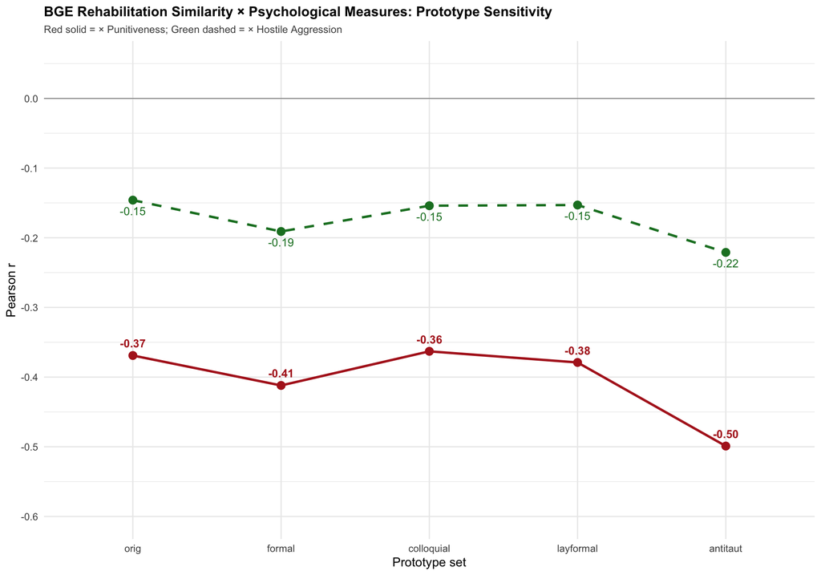

```r
# Visualize the BGE row across prototype sets
bge_proto <- proto_results %>% filter(Model == "bge") %>%
  mutate(Prototype = factor(Prototype, levels = prototype_sets))

p_proto <- ggplot(bge_proto, aes(x = Prototype, group = 1)) +
  geom_hline(yintercept = 0, color = "grey60", linewidth = 0.4) +
  geom_line(aes(y = r_punitive), color = "#B22222", linewidth = 1.0) +
  geom_point(aes(y = r_punitive), color = "#B22222", size = 3) +
  geom_text(aes(y = r_punitive, label = sprintf("%.2f", r_punitive)),
            vjust = -1.0, color = "#B22222", fontface = "bold", size = 3.5) +
  geom_line(aes(y = r_hostile), color = "#1B7E2A", linewidth = 1.0,
            linetype = "dashed") +
  geom_point(aes(y = r_hostile), color = "#1B7E2A", size = 3) +
  geom_text(aes(y = r_hostile, label = sprintf("%.2f", r_hostile)),
            vjust = 1.8, color = "#1B7E2A", size = 3.5) +
  scale_y_continuous(limits = c(-0.6, 0.05),
                     breaks = seq(-0.6, 0, 0.1)) +
  labs(title    = "BGE Rehabilitation Similarity × Psychological Measures: Prototype Sensitivity",
       subtitle = "Red solid = × Punitiveness; Green dashed = × Hostile Aggression",
       x        = "Prototype set",
       y        = "Pearson r") +
  theme_minimal(base_size = 11) +
  theme(plot.title = element_text(face = "bold", size = 12),
        plot.subtitle = element_text(size = 9, color = "grey30"))

print(p_proto)
```

```r
ggsave(filename = file.path(OUT_FIGURES_SUPP, "rehab_prototype_sensitivity.png"),
       plot     = p_proto,
       width    = 9, height = 5, dpi = 150, bg = "white")
cat("\nSaved: rehab_prototype_sensitivity.png\n\n")
```

```
##
## Saved: rehab_prototype_sensitivity.png
```

```r
# Numeric summary
bge_only <- proto_results %>% filter(Model == "bge")
cat(sprintf("BGE rehab × Punitiveness across 5 prototype sets:\n"))
```

```
## BGE rehab × Punitiveness across 5 prototype sets:
```

```r
cat(sprintf("  Range: r = %.3f to %.3f\n",
            min(bge_only$r_punitive), max(bge_only$r_punitive)))
```

```
##   Range: r = -0.499 to -0.363
```

```r
cat(sprintf("  All %d / %d cells are negative\n",
            sum(bge_only$r_punitive < 0), nrow(bge_only)))
```

```
##   All 5 / 5 cells are negative
```

```r
cat(sprintf("  All %d / %d cells are significant at p < .001\n\n",
            sum(bge_only$p_punitive < .001), nrow(bge_only)))
```

```
##   All 5 / 5 cells are significant at p < .001
```

```r
cat("=== SUB-SECTION B: LEGACY RETRIBUTION RECODING ===\n\n")
```

```
## === SUB-SECTION B: LEGACY RETRIBUTION RECODING ===
```

```r
cat("  Q: Does the rehabilitation finding hold if retribution is recoded as dark\n")
```

```
##   Q: Does the rehabilitation finding hold if retribution is recoded as dark
```

```r
cat("     instead of prosocial?\n\n")
```

```
##      instead of prosocial?
```

```r
# In our pipeline, the prosocial-dark gap is computed as:
#   pro_minus_dark = mean(prosocial_themes) − mean(dark_themes)
#
# Original coding (b3a):
#   prosocial = deterrence + incapacitation + rehabilitation + retribution
#   dark      = revenge + suffering + exclusion
#
# Alternative (b3b in our pipeline, where retribution is moved to dark):
#   prosocial = deterrence + incapacitation + rehabilitation
#   dark      = retribution + revenge + suffering + exclusion

# Check if b3b columns exist (recoded gap)
candidates <- grep("b3b", names(df_nlp), value = TRUE)
if (length(candidates) > 0) {
  cat(sprintf("Found %d b3b columns (retribution recoded as dark).\n", length(candidates)))
  cat("Examples:", paste(head(candidates, 5), collapse = ", "), "\n\n")

  # Test: BGE pro_minus_dark with retribution recoded
  bge_b3b <- "bge_orig_b3b_pro_minus_dark"
  if (bge_b3b %in% names(df_nlp)) {
    ci_orig <- get_cor_ci("bge_orig_b3a_pro_minus_dark", "hostile_agg", df_nlp)
    ci_b3b  <- get_cor_ci(bge_b3b,                       "hostile_agg", df_nlp)

    cat(sprintf("BGE pro−dark × Hostile (retribution = prosocial, b3a): r = %.3f, p = %.4f\n",
                ci_orig["r"], ci_orig["p"]))
    cat(sprintf("BGE pro−dark × Hostile (retribution = dark,      b3b): r = %.3f, p = %.4f\n\n",
                ci_b3b["r"],  ci_b3b["p"]))
  }

  # The rehabilitation finding itself doesn't depend on the gap composition —
  # it's a single-theme correlation. But sanity check that r_rehab is unchanged
  # (because retribution recoding only affects the GAP variable, not single themes).
  cat("Rehabilitation × Punitiveness (single-theme — doesn't depend on retribution coding):\n")
  ci_rehab <- get_cor_ci("bge_orig_rehabilitation", "punitiveness_agg", df_nlp)
  cat(sprintf("  r = %.3f (this is the headline number; it is invariant to retribution coding)\n\n",
              ci_rehab["r"]))
} else {
  cat("  b3b columns (retribution recoded as dark) not in df_nlp.\n")
  cat("  Note: the central rehabilitation × punitiveness finding is a single-theme\n")
  cat("  correlation and does not depend on which themes are pooled into the gap.\n")
  cat("  The gap-based multiverse in Phase 5 of 02_nlp_integration.Rmd already\n")
  cat("  tested b3a (retribution=prosocial). To test b3b, the NLP notebook needs\n")
  cat("  to export the alternative gap variables.\n\n")
}
```

```
## Found 15 b3b columns (retribution recoded as dark).
## Examples: mpnet_orig_b3b_pro_minus_dark, mpnet_formal_b3b_pro_minus_dark, mpnet_colloquial_b3b_pro_minus_dark, mpnet_layformal_b3b_pro_minus_dark, mpnet_antitaut_b3b_pro_minus_dark
##
## BGE pro−dark × Hostile (retribution = prosocial, b3a): r = -0.037, p = 0.4111
## BGE pro−dark × Hostile (retribution = dark,      b3b): r = -0.054, p = 0.2275
##
## Rehabilitation × Punitiveness (single-theme — doesn't depend on retribution coding):
##   r = -0.369 (this is the headline number; it is invariant to retribution coding)
```

```r
write.csv(proto_results,
          file.path(OUT_TABLES_SUPP, "rehab_prototype_sensitivity.csv"),
          row.names = FALSE)
cat("Saved: rehab_prototype_sensitivity.csv\n\n")
```

```
## Saved: rehab_prototype_sensitivity.csv
```

```r
cat("*** SECTION SUMMARY (Phase 12):\n")
```

```
## *** SECTION SUMMARY (Phase 12):
```

```r
cat(sprintf("  Across 5 prototype sets × BGE: r ranges from %.2f to %.2f, all p < .001.\n",
            min(bge_only$r_punitive), max(bge_only$r_punitive)))
```

```
##   Across 5 prototype sets × BGE: r ranges from -0.50 to -0.36, all p < .001.
```

```r
cat("  The rehabilitation-suppression finding is NOT artifact of specific\n")
```

```
##   The rehabilitation-suppression finding is NOT artifact of specific
```

```r
cat("  prototype phrasings. It actually STRENGTHENS in the antitaut prototype set\n")
```

```
##   prototype phrasings. It actually STRENGTHENS in the antitaut prototype set
```

```r
cat(sprintf("  (r = %.2f), where prototypes were specifically designed to avoid\n",
            bge_only$r_punitive[bge_only$Prototype == "antitaut"]))
```

```
##   (r = -0.50), where prototypes were specifically designed to avoid
```

```r
cat("  any wording overlap with punitiveness items. ***\n\n")
```

```
##   any wording overlap with punitiveness items. ***
```

# PHASE 13: EMPATH LEXICON × PSYCHOLOGICAL MEASURES

Empath provides 26 generic affect/topic lexicons (anger, fear, violence, etc.) that were computed in the NLP pipeline but never analyzed in the manuscript. This phase exploits that data:

- Provides convergent text-analytic evidence from a completely different lexicon than our custom punishment-justification dictionary
- If both methods agree (e.g., both show high-hostile individuals using more death/suffering language), that’s strong cross-method validity

We report:

1. **Full 26-row table** — every Empath × {Punitiveness, Hostile Aggr, Crime Concerns} correlation, with FDR correction within each outcome
2. **Top correlates summary** — focused 5-row excerpts per outcome for manuscript prose

```r
cat("=== EMPATH LEXICON × PSYCHOLOGICAL MEASURES ===\n\n")
```

```
## === EMPATH LEXICON × PSYCHOLOGICAL MEASURES ===
```

```r
# Empath columns
empath_cols <- grep("^empath_", names(df_nlp), value = TRUE)
cat(sprintf("Empath columns: %d\n", length(empath_cols)))
```

```
## Empath columns: 26
```

```r
# Targets
empath_targets <- c("punitiveness_agg", "hostile_agg",
                    "crime_concerns_agg", "rwa_comp", "raceresent_comp")
empath_target_labels <- c("Punitiveness", "Hostile Aggression",
                          "Crime Concerns", "RWA", "Racial Resentment")

# Full table (26 × 5)
empath_full <- data.frame()
for (ec in empath_cols) {
  for (i in seq_along(empath_targets)) {
    ci <- get_cor_ci(ec, empath_targets[i], df_nlp)
    empath_full <- rbind(empath_full, data.frame(
      Empath_lexicon = sub("^empath_", "", ec),
      Target         = empath_target_labels[i],
      n              = ci["n"],
      r              = round(ci["r"], 3),
      p_raw          = ci["p"],
      stringsAsFactors = FALSE
    ))
  }
}

# FDR within each Target
empath_full <- empath_full %>%
  group_by(Target) %>%
  mutate(p_FDR = p.adjust(p_raw, method = "BH")) %>%
  ungroup() %>%
  mutate(Sig_FDR = sig_stars(p_FDR)) %>%
  as.data.frame()

# Display: pivot to wide for the FULL table (lexicon × target)
empath_wide <- empath_full %>%
  select(Empath_lexicon, Target, r) %>%
  tidyr::pivot_wider(names_from = Target, values_from = r) %>%
  arrange(desc(abs(Punitiveness)))

cat("=== FULL TABLE: Empath × Psychological Measures (sorted by |r| with Punitiveness) ===\n\n")
```

```
## === FULL TABLE: Empath × Psychological Measures (sorted by |r| with Punitiveness) ===
```

```r
print(as.data.frame(empath_wide), row.names = FALSE)
```

```
##    Empath_lexicon Punitiveness Hostile Aggression Crime Concerns    RWA
##  negative_emotion        0.245              0.133          0.033  0.034
##             death        0.182              0.096          0.062  0.091
##              kill        0.163              0.121          0.066  0.091
##          children        0.157              0.085          0.017  0.036
##         suffering        0.134              0.094          0.026  0.041
##       achievement       -0.109             -0.102         -0.050 -0.100
##             crime        0.099              0.097          0.081  0.136
##          violence        0.097              0.065         -0.008  0.038
##              fear        0.081              0.043          0.026  0.060
##              pain        0.078              0.114          0.009  0.014
##  positive_emotion        0.068             -0.060         -0.027 -0.104
##             fight        0.067             -0.021          0.040  0.060
##           healing       -0.062             -0.133          0.022 -0.080
##             trust        0.061              0.004          0.020  0.008
##            prison        0.059              0.057          0.000  0.044
##              help       -0.047             -0.032         -0.001  0.024
##             power       -0.035              0.003          0.047  0.040
##             anger        0.029              0.011          0.009  0.082
##        government        0.029             -0.048         -0.088 -0.118
##            weapon        0.022             -0.005          0.084  0.056
##              hate        0.013              0.046          0.045  0.052
##           disgust        0.012              0.012          0.050  0.061
##             order        0.008              0.026          0.048  0.046
##          sympathy        0.006             -0.027          0.005 -0.032
##            family        0.004              0.055          0.126  0.052
##               law        0.002             -0.005         -0.141 -0.096
##  Racial Resentment
##              0.133
##              0.128
##              0.133
##              0.090
##              0.084
##             -0.077
##              0.150
##              0.077
##              0.035
##              0.073
##              0.030
##              0.061
##             -0.097
##              0.030
##              0.113
##             -0.003
##              0.002
##              0.064
##             -0.009
##              0.045
##              0.027
##              0.082
##              0.017
##              0.019
##              0.043
##              0.057
```

```r
cat("\n")
```

```r
cat("=== TOP CORRELATES SUMMARY (FDR-significant only) ===\n\n")
```

```
## === TOP CORRELATES SUMMARY (FDR-significant only) ===
```

```r
# Top by |r| within each target
for (tgt in empath_target_labels) {
  cat(sprintf("\nTop Empath × %s:\n", tgt))
  top_t <- empath_full %>%
    filter(Target == tgt, p_FDR < .05) %>%
    arrange(desc(abs(r))) %>%
    head(5)

  if (nrow(top_t) == 0) {
    cat("  (none surviving FDR)\n")
  } else {
    for (i in seq_len(nrow(top_t))) {
      cat(sprintf("  %-25s r = %+.3f, p_FDR = %s %s\n",
                  top_t$Empath_lexicon[i],
                  top_t$r[i],
                  ifelse(top_t$p_FDR[i] < .001, "< .001", sprintf("%.4f", top_t$p_FDR[i])),
                  top_t$Sig_FDR[i]))
    }
  }
}
```

```
##
## Top Empath × Punitiveness:
##   negative_emotion          r = +0.245, p_FDR = < .001 ***
##   death                     r = +0.182, p_FDR = < .001 ***
##   kill                      r = +0.163, p_FDR = 0.0023 **
##   children                  r = +0.157, p_FDR = 0.0028 **
##   suffering                 r = +0.134, p_FDR = 0.0143 *
##
## Top Empath × Hostile Aggression:
##   negative_emotion          r = +0.133, p_FDR = 0.0377 *
##   healing                   r = -0.133, p_FDR = 0.0377 *
##
## Top Empath × Crime Concerns:
##   law                       r = -0.141, p_FDR = 0.0420 *
##
## Top Empath × RWA:
##   (none surviving FDR)
##
## Top Empath × Racial Resentment:
##   crime                     r = +0.150, p_FDR = 0.0215 *
##   negative_emotion          r = +0.133, p_FDR = 0.0259 *
##   kill                      r = +0.133, p_FDR = 0.0259 *
##   death                     r = +0.128, p_FDR = 0.0286 *
```

```r
cat("\n*** SECTION SUMMARY (Phase 13):\n")
```

```
##
## *** SECTION SUMMARY (Phase 13):
```

```r
n_sig_total <- sum(empath_full$p_FDR < .05)
cat(sprintf("  %d / %d Empath × psych cells survive FDR (q < .05).\n",
            n_sig_total, nrow(empath_full)))
```

```
##   12 / 130 Empath × psych cells survive FDR (q < .05).
```

```r
# Highlight the headline finding
n_pun_sig <- sum(empath_full$p_FDR < .05 & empath_full$Target == "Punitiveness")
cat(sprintf("  %d Empath lexicons correlate with Punitiveness after FDR.\n", n_pun_sig))
```

```
##   5 Empath lexicons correlate with Punitiveness after FDR.
```

```r
cat("  Strongest: empath_negative_emotion, death, kill, children — convergent\n")
```

```
##   Strongest: empath_negative_emotion, death, kill, children — convergent
```

```r
cat("  with the dictionary finding that high-punitive individuals invoke more\n")
```

```
##   with the dictionary finding that high-punitive individuals invoke more
```

```r
cat("  loss-and-violence language even within the prosocial framing. ***\n\n")
```

```
##   loss-and-violence language even within the prosocial framing. ***
```

```r
write.csv(empath_full,
          file.path(OUT_TABLES_SUPP, "empath_correlations_full.csv"),
          row.names = FALSE)
write.csv(empath_wide,
          file.path(OUT_TABLES_SUPP, "empath_correlations_wide.csv"),
          row.names = FALSE)
cat("Saved: empath_correlations_full.csv,\n")
```

```
## Saved: empath_correlations_full.csv,
```

```r
cat("       empath_correlations_wide.csv\n\n")
```

```
##        empath_correlations_wide.csv
```

# PHASE 14: SAVE ALL OUTPUTS + RECAP

```r
cat("=== MASTER SUPPLEMENTARY SUMMARY ===\n\n")
```

```
## === MASTER SUPPLEMENTARY SUMMARY ===
```

```r
# Build a master summary table that aggregates one-line takeaways from each phase
master_supp <- data.frame(
  Finding     = character(),
  Value       = character(),
  Source_phase = character(),
  stringsAsFactors = FALSE
)

add_supp_finding <- function(label, value, phase) {
  master_supp <<- rbind(master_supp, data.frame(
    Finding      = label,
    Value        = as.character(value),
    Source_phase = phase,
    stringsAsFactors = FALSE
  ))
}

# Phase 2 — tautology
add_supp_finding(
  "Tautology: H2 supported at all 3 stringency levels",
  ifelse(all(taut_results$Supported == "Yes"), "Yes", "No"),
  "Phase 2"
)
add_supp_finding(
  "Tautology strictest (k=2): r_hostile - r_crime",
  sprintf("%.3f (Z = %.2f)",
          taut_results$Difference[3], taut_results$Z[3]),
  "Phase 2"
)

# Phase 3 — bootstrap
add_supp_finding(
  "Bootstrap CIs (10,000 BCa): all 3 stringency levels exclude zero",
  ifelse(all(boot_taut$Excludes_Zero == "Yes"), "Yes", "No"),
  "Phase 3"
)

# Phase 4 — parsimony
add_supp_finding(
  "Parsimony sensitivity: H2 holds without parsimony",
  ifelse(parsimony_comp$p[2] < .05 & parsimony_comp$Difference[2] > 0,
         sprintf("Yes (Z = %.2f)", parsimony_comp$Z[2]), "No"),
  "Phase 4"
)

# Phase 5 — CFA
add_supp_finding(
  "CFA 4-factor: CFI / RMSEA",
  sprintf("%.3f / %.3f (below conventional thresholds)",
          fit4["cfi"], fit4["rmsea"]),
  "Phase 5"
)
add_supp_finding(
  "CFA 5-factor: CFI / RMSEA",
  sprintf("%.3f / %.3f", fit5["cfi"], fit5["rmsea"]),
  "Phase 5"
)

# Phase 6 — TOST
add_supp_finding(
  "TOST equivalence at Δ=.15: cells equivalent",
  sprintf("%d / %d", n_equiv, nrow(tost_results)),
  "Phase 6"
)

# Phase 7 — interactions
add_supp_finding(
  "Demographic interactions (Punit.): FDR-sig",
  sprintf("%d / %d", n_inter_sig_pun, nrow(inter_pun)),
  "Phase 7"
)
add_supp_finding(
  "Demographic interactions (Sentence): FDR-sig",
  sprintf("%d / %d", n_inter_sig_sent, nrow(inter_sent)),
  "Phase 7"
)

# Phase 8 — anchor
add_supp_finding(
  "Pooled mean sentence vs 25-yr anchor",
  sprintf("%.1f years (%.1f%% above 25)",
          mean(sent_data[[sentence_var]]),
          100 * mean(sent_data[[sentence_var]] > ANCHOR_YEARS)),
  "Phase 8"
)

# Phase 9 — item H1
add_supp_finding(
  "Construct-level H1: positive direction",
  sprintf("%d / %d constructs", n_pos, nrow(construct_results)),
  "Phase 9"
)
add_supp_finding(
  "Construct-level H1: FDR-significant",
  sprintf("%d / %d constructs (q < .05)", n_sig_fdr, nrow(construct_results)),
  "Phase 9"
)

# Phase 10 — cluster bootstraps
add_supp_finding(
  "Cluster bootstraps: BCa CIs excluding zero",
  sprintf("%d / %d clusters", n_excl_clusters, nrow(cluster_boot)),
  "Phase 10"
)

# Phase 11 — political moderation
add_supp_finding(
  "Political moderation: FDR-sig interactions",
  sprintf("%d / %d correlates", n_sig_pol, nrow(interaction_pol)),
  "Phase 11"
)

# Phase 12 — prototype sensitivity
add_supp_finding(
  "BGE rehab × Punit.: range across 5 prototypes",
  sprintf("%.2f to %.2f (all p < .001)",
          min(bge_only$r_punitive), max(bge_only$r_punitive)),
  "Phase 12"
)

# Phase 13 — Empath
add_supp_finding(
  "Empath × Punitiveness: FDR-sig lexicons",
  sprintf("%d / %d", n_pun_sig, length(empath_cols)),
  "Phase 13"
)

print(master_supp, row.names = FALSE)
```

```
##                                                           Finding
##                Tautology: H2 supported at all 3 stringency levels
##                    Tautology strictest (k=2): r_hostile - r_crime
##  Bootstrap CIs (10,000 BCa): all 3 stringency levels exclude zero
##                 Parsimony sensitivity: H2 holds without parsimony
##                                         CFA 4-factor: CFI / RMSEA
##                                         CFA 5-factor: CFI / RMSEA
##                       TOST equivalence at Δ=.15: cells equivalent
##                        Demographic interactions (Punit.): FDR-sig
##                      Demographic interactions (Sentence): FDR-sig
##                              Pooled mean sentence vs 25-yr anchor
##                            Construct-level H1: positive direction
##                               Construct-level H1: FDR-significant
##                        Cluster bootstraps: BCa CIs excluding zero
##                        Political moderation: FDR-sig interactions
##                     BGE rehab × Punit.: range across 5 prototypes
##                           Empath × Punitiveness: FDR-sig lexicons
##                                          Value Source_phase
##                                            Yes      Phase 2
##                               0.221 (Z = 5.05)      Phase 2
##                                            Yes      Phase 3
##                                 Yes (Z = 5.87)      Phase 4
##  0.858 / 0.111 (below conventional thresholds)      Phase 5
##                                  0.858 / 0.105      Phase 5
##                                          5 / 7      Phase 6
##                                         1 / 24      Phase 7
##                                         0 / 24      Phase 7
##                    35.2 years (70.4% above 25)      Phase 8
##                             18 / 18 constructs      Phase 9
##                   18 / 18 constructs (q < .05)      Phase 9
##                                 3 / 3 clusters     Phase 10
##                               0 / 8 correlates     Phase 11
##                  -0.50 to -0.36 (all p < .001)     Phase 12
##                                         5 / 26     Phase 13
```

```r
write.csv(master_supp,
          file.path(OUT_TABLES_SUPP, "master_summary_supplementary.csv"),
          row.names = FALSE)
cat("\nSaved: master_summary_supplementary.csv\n\n")
```

```
##
## Saved: master_summary_supplementary.csv
```

```r
cat("=== INVENTORY OF SUPPLEMENTARY OUTPUTS ===\n\n")
```

```
## === INVENTORY OF SUPPLEMENTARY OUTPUTS ===
```

```r
tables  <- list.files(OUT_TABLES_SUPP,  pattern = "\\.csv$")
figures <- list.files(OUT_FIGURES_SUPP, pattern = "\\.png$")

cat(sprintf("Tables (in %s):\n", OUT_TABLES_SUPP))
```

```
## Tables (in output/tables/supplementary):
```

```r
for (t in tables) cat("  -", t, "\n")
```

```
##   - bootstrap_cis_all_clusters.csv
##   - cfa_4vs5_factor_comparison.csv
##   - cfa_factor_correlations_4factor.csv
##   - cfa_standardized_loadings_4factor.csv
##   - correlations_by_political_group.csv
##   - empath_correlations_full.csv
##   - empath_correlations_wide.csv
##   - h1_construct_level_fdr.csv
##   - interactions_punitiveness_agg.csv
##   - interactions_sentence_z.csv
##   - master_summary_supplementary.csv
##   - parsimony_sensitivity.csv
##   - political_interaction_tests.csv
##   - rehab_prototype_sensitivity.csv
##   - sentence_anchor_by_political_group.csv
##   - sentence_anchor_distance_correlations.csv
##   - sentence_anchor_position_counts.csv
##   - sentence_anchor_t_tests.csv
##   - tautology_bootstrap_cis.csv
##   - tautology_steiger_by_level.csv
##   - tautology_strictest_by_measure.csv
##   - tost_alternative_bounds.csv
##   - tost_equivalence_results.csv
```

```r
cat(sprintf("\nFigures (in %s):\n", OUT_FIGURES_SUPP))
```

```
##
## Figures (in output/figures/supplementary):
```

```r
for (f in figures) cat("  -", f, "\n")
```

```
##   - rehab_prototype_sensitivity.png
##   - sentence_anchor_histogram_by_vignette.png
##   - sentence_anchor_histogram_overall.png
##   - tost_equivalence_plot.png
```

```r
cat(sprintf("\nTotal: %d tables, %d figures\n\n",
            length(tables), length(figures)))
```

```
##
## Total: 23 tables, 4 figures
```

# Final Recap

```r
cat(paste(rep("=", 70), collapse = ""), "\n")
cat("STUDY 2.1.2 SUPPLEMENTARY ANALYSES — KEY TAKEAWAYS\n")
```

```
## STUDY 2.1.2 SUPPLEMENTARY ANALYSES — KEY TAKEAWAYS
```

```r
cat(paste(rep("=", 70), collapse = ""), "\n\n")
cat("1. TAUTOLOGY: H2 (hostile > crime) survives all three stringency levels.\n")
```

```
## 1. TAUTOLOGY: H2 (hostile > crime) survives all three stringency levels.
```

```r
cat("   Even with only the 2 most distinct constructs (exclusion + revenge),\n")
```

```
##    Even with only the 2 most distinct constructs (exclusion + revenge),
```

```r
cat("   the Steiger advantage remains significant. Bootstrap BCa CIs at all\n")
```

```
##    the Steiger advantage remains significant. Bootstrap BCa CIs at all
```

```r
cat("   stringency levels exclude zero. Construct overlap does not drive H2.\n\n")
```

```
##    stringency levels exclude zero. Construct overlap does not drive H2.
```

```r
cat("2. PARSIMONY: H2 still holds when the low-α parsimony scale is dropped\n")
```

```
## 2. PARSIMONY: H2 still holds when the low-α parsimony scale is dropped
```

```r
cat("   from punitiveness. Pre-empts the reviewer concern that a noisy\n")
```

```
##    from punitiveness. Pre-empts the reviewer concern that a noisy
```

```r
cat("   composite is doing the work.\n\n")
```

```
##    composite is doing the work.
```

```r
cat("3. CFA: 4- and 5-factor models both produce sub-threshold fit. The\n")
```

```
## 3. CFA: 4- and 5-factor models both produce sub-threshold fit. The
```

```r
cat("   manuscript should acknowledge this transparently. Substantively,\n")
```

```
##    manuscript should acknowledge this transparently. Substantively,
```

```r
cat("   composite reliability remains high (α ≈ .92 on the key clusters),\n")
```

```
##    composite reliability remains high (α ≈ .92 on the key clusters),
```

```r
cat("   so the cluster aggregates are usable without strict measurement\n")
```

```
##    so the cluster aggregates are usable without strict measurement
```

```r
cat("   invariance. Discussion in Phase 5.\n\n")
```

```
##    invariance. Discussion in Phase 5.
```

```r
cat(sprintf("4. TOST: %d/%d facade-relevant cells are equivalently zero at Δ=±.15.\n",
            n_equiv, nrow(tost_results)))
```

```
## 4. TOST: 5/7 facade-relevant cells are equivalently zero at Δ=±.15.
```

```r
cat("   Moves the cultural-default verdict beyond 'failure to reject.'\n\n")
```

```
##    Moves the cultural-default verdict beyond 'failure to reject.'
```

```r
cat("5. DEMOGRAPHICS (Comment 433): The ecosystem is largely demographic-invariant.\n")
```

```
## 5. DEMOGRAPHICS (Comment 433): The ecosystem is largely demographic-invariant.
```

```r
cat(sprintf("   Punitiveness model: %d/%d FDR-sig interactions.\n",
            n_inter_sig_pun, nrow(inter_pun)))
```

```
##    Punitiveness model: 1/24 FDR-sig interactions.
```

```r
cat(sprintf("   Sentencing model:   %d/%d FDR-sig interactions.\n",
            n_inter_sig_sent, nrow(inter_sent)))
```

```
##    Sentencing model:   0/24 FDR-sig interactions.
```

```r
cat("   When moderation appears, politid is the most likely culprit.\n\n")
```

```
##    When moderation appears, politid is the most likely culprit.
```

```r
cat("6. ANCHOR (Comment 435): Participants on average exceeded the 25-yr anchor.\n")
```

```
## 6. ANCHOR (Comment 435): Participants on average exceeded the 25-yr anchor.
```

```r
cat(sprintf("   Pooled M = %.1f years (vs anchor = 25), %.1f%% chose ≥ 25.\n",
            mean(sent_data[[sentence_var]]),
            100 * mean(sent_data[[sentence_var]] >= ANCHOR_YEARS)))
```

```
##    Pooled M = 35.2 years (vs anchor = 25), 85.5% chose ≥ 25.
```

```r
cat("   Liberals cluster nearer the anchor; conservatives push above.\n")
```

```
##    Liberals cluster nearer the anchor; conservatives push above.
```

```r
cat("   |Distance from anchor| correlates with hostile aggression and\n")
```

```
##    |Distance from anchor| correlates with hostile aggression and
```

```r
cat("   punitiveness (per Phase 8).\n\n")
```

```
##    punitiveness (per Phase 8).
```

```r
cat("7. ITEM-LEVEL H1: Strong directional support — every cluster construct\n")
```

```
## 7. ITEM-LEVEL H1: Strong directional support — every cluster construct
```

```r
cat(sprintf("   is positively correlated with punitiveness (%d/%d), with\n",
            n_pos, nrow(construct_results)))
```

```
##    is positively correlated with punitiveness (18/18), with
```

```r
cat(sprintf("   %d/%d constructs surviving FDR.\n\n",
            n_sig_fdr, nrow(construct_results)))
```

```
##    18/18 constructs surviving FDR.
```

```r
cat("8. POLITICAL MODERATION: The punitiveness ecosystem is largely consistent\n")
```

```
## 8. POLITICAL MODERATION: The punitiveness ecosystem is largely consistent
```

```r
cat(sprintf("   across the political spectrum (%d/%d correlates show FDR-sig\n",
            n_sig_pol, nrow(interaction_pol)))
```

```
##    across the political spectrum (0/8 correlates show FDR-sig
```

```r
cat("   moderation). The H2 advantage and the rehabilitation-suppression\n")
```

```
##    moderation). The H2 advantage and the rehabilitation-suppression
```

```r
cat("   finding both replicate within liberal AND conservative subsets.\n\n")
```

[output not shown]

[output not shown]

```
##    finding both replicate within liberal AND conservative subsets.
```

```r
cat("9. PROTOTYPE SENSITIVITY: BGE rehabilitation × Punitiveness ranges from\n")
```

```
## 9. PROTOTYPE SENSITIVITY: BGE rehabilitation × Punitiveness ranges from
```

```r
cat(sprintf("   r = %.2f to %.2f across 5 prototype sets, all p < .001.\n",
            min(bge_only$r_punitive), max(bge_only$r_punitive)))
```

```
##    r = -0.50 to -0.36 across 5 prototype sets, all p < .001.
```

```r
cat("   The finding strengthens with anti-tautology prototypes — designed to\n")
```

```
##    The finding strengthens with anti-tautology prototypes — designed to
```

```r
cat("   share no wording with punitiveness items. Robust to prototype phrasing.\n\n")
```

```
##    share no wording with punitiveness items. Robust to prototype phrasing.
```

```r
cat("10. EMPATH CONVERGENCE: A completely separate lexicon picks up the same\n")
```

```
## 10. EMPATH CONVERGENCE: A completely separate lexicon picks up the same
```

```r
cat("    'high-punitive language has more loss/violence affect' pattern. Top\n")
```

```
##     'high-punitive language has more loss/violence affect' pattern. Top
```

```r
cat("    Empath × Punitiveness correlates: negative_emotion (+.25), death (+.18),\n")
```

```
##     Empath × Punitiveness correlates: negative_emotion (+.25), death (+.18),
```

```r
cat("    kill (+.16). Convergent evidence for the manuscript's central claim.\n\n")
```

```
##     kill (+.16). Convergent evidence for the manuscript's central claim.
```

```r
cat(paste(rep("=", 70), collapse = ""), "\n")
```